# Range through time diversity analysis

## 1.8 Building the chart

### 1.8.1 Setting up the figure and axes

You already know the `Figure` / `Axis` pattern. Two new axis options appear here:

- **`yticks`** takes a pair `(positions, labels)` — numeric positions on the y-axis and the text labels to show at those positions. We use `1:nrow(appearance_df)` as positions (one integer per genus) and `appearance_df.genus` as the labels.
- **`xreversed = true`** flips the x-axis so that older ages (larger numbers) are on the left, matching the geological convention.

```julia
using Makie, CairoMakie

fig = Figure()
ax = Axis(
    fig[1, 1],
    xlabel = "Midpoint age (Ma)",
    ylabel = "Genus",
    yticks = (1:nrow(appearance_df), appearance_df.genus),
    xreversed = true
)
```

```
Makie.Axis with 0 plots:
```

### 1.8.2 Drawing the lines with a loop

We need one horizontal line per genus. We *could* write out `lines!()` once for each genus by hand — but that would be tedious, error-prone, and would break the moment the number of genera changed.

Instead we use a **`for` loop**: write the instruction once, and tell Julia to repeat it for each genus automatically.

The basic structure is:

```julia
for i in 1:5
    println(i)
end
```

`1:5` is a *range* — the values 1, 2, 3, 4, 5. On each pass through the loop, `i` takes the next value from the range. Everything between `for` and `end` runs once per value.

In our case the range is `1:nrow(appearance_df)` — one integer for each row (i.e. each genus) in our summary table. We use `i` for two purposes simultaneously:

- As a **row index** to look up that genus’s dates: `appearance_df.first_appearance_datum[i]`
- As the **y-position** of the line on the chart (genus 1 at height 1, genus 2 at height 2, …).

`lines!(ax, [x1, x2], [i, i])` draws a horizontal segment: the x-coordinates go from `x1` to `x2`, and both y-coordinates are `i`, so the line is flat at that height.

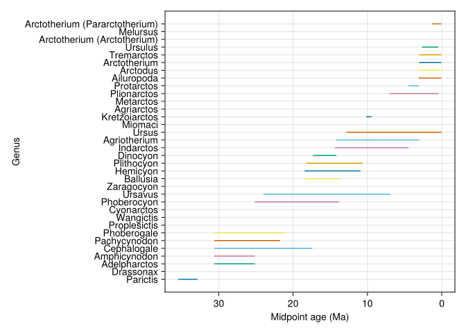

```julia
for i in 1:nrow(appearance_df)
    x1 = appearance_df.first_appearance_datum[i]
    x2 = appearance_df.last_appearance_datum[i]
    lines!(ax, [x1, x2], [i, i])
end

fig
```

## 1.9 Complete program

For reference, here is the full program in one place:

```julia
using DataFrames
using PaleobiologyDB
using PaleobiologyDB.Taxonomy
using Makie, CairoMakie

PaleobiologyDB.set_autocaching!(true);

using PaleobiologyDB

df_raw = pbdb_occurrences(
    base_name = "Ursidae";
    show = "full",
    vocab = "pbdb"
)

using DataFrames

df = dropmissing(df_raw, [
    :genus,
    :early_interval,
    :max_ma,
    :min_ma
])

using PaleobiologyDB.Taxonomy: drop_unresolved_taxa
df = drop_unresolved_taxa(df, "genus")

using PaleobiologyDB.Taxonomy: drop_unrecognized_taxa
df = Taxonomy.drop_unrecognized_taxa(df, :genus)

df.midpoint_age = (df.max_ma .+ df.min_ma) ./ 2

df = sort(df, [:genus, :midpoint_age])

appearance_df = combine(
    groupby(df, :genus; sort = true),
    :midpoint_age => maximum => :first_appearance_datum,
    :midpoint_age => minimum => :last_appearance_datum
)

appearance_df = sort(appearance_df, :first_appearance_datum, rev=true)

using Makie, CairoMakie

fig = Figure()
ax = Axis(
    fig[1, 1],
    xlabel = "Midpoint age (Ma)",
    ylabel = "Genus",
    yticks = (1:nrow(appearance_df), appearance_df.genus),
    xreversed = true
)

for i in 1:nrow(appearance_df)
    x1 = appearance_df.first_appearance_datum[i]
    x2 = appearance_df.last_appearance_datum[i]
    lines!(ax, [x1, x2], [i, i])
end

fig
```

## 1.10 Exercises: Calculating ranges through time

### 1.10.1 Julia concepts and mechanisms

For each snippet, read the code and predict what it will print *before* you run it. Then try it in the REPL to check.

#### 1.10.1.1 Part A: Vectorised operations

1. Dividing every element:

   ```julia
   a = [10.0, 20.0, 30.0]
   println(a ./ 10.0)
   ```

   **NoteAnswer**

   ```
   [1.0, 2.0, 3.0]
   ```

   `./ 10.0` divides each element of `a` by 10 independently.
2. Adding two arrays element-by-element:

   ```julia
   max_ma = [40.0, 20.0]
   min_ma = [30.0, 10.0]
   println(max_ma .+ min_ma)
   ```

   **NoteAnswer**

   ```
   [70.0, 30.0]
   ```

3. Computing midpoints:

   ```julia
   max_ma = [55.0, 33.9, 23.0]
   min_ma = [33.9, 23.0,  5.3]
   midpoints = (max_ma .+ min_ma) ./ 2
   println(midpoints)
   ```

   **NoteAnswer**

   ```
   [44.45, 28.45, 14.15]
   ```

   `.+` adds corresponding elements; `./ 2` then divides each result.
4. Dot multiplication:

   ```julia
   ages = [10.0, 20.0, 30.0]
   println(ages .* 2.0)
   ```

   **NoteAnswer**

   ```
   [20.0, 40.0, 60.0]
   ```

5. Subtracting a scalar from every element:

   ```julia
   ages = [50.0, 30.0, 10.0]
   println(ages .- 5.0)
   ```

   **NoteAnswer**

   ```
   [45.0, 25.0, 5.0]
   ```

6. Chaining dot operations:

   ```julia
   a = [8.0, 16.0, 24.0]
   b = [2.0,  4.0,  6.0]
   println((a .+ b) ./ 2.0)
   ```

   **NoteAnswer**

   ```
   [5.0, 10.0, 15.0]
   ```

   The parentheses force `.+` first; `./ 2.0` then halves each sum.

#### 1.10.1.2 Part B: Loops and indexing

1. A basic `for` loop:

   ```julia
   for i in 1:4
       println(i * 10)
   end
   ```

   **NoteAnswer**

   ```
   10
   20
   30
   40
   ```

   `i` takes each value in the range `1:4` in turn.
2. Using `i` as both an index and a display number:

   ```julia
   genera = ["Ursus", "Ailuropoda", "Indarctos"]
   for i in 1:3
       println(i, ". ", genera[i])
   end
   ```

   **NoteAnswer**

   ```
   1. Ursus
   2. Ailuropoda
   3. Indarctos
   ```

   This is the same dual role `i` plays in the range chart: row index *and* y-position.
3. Squaring inside a loop:

   ```julia
   for i in 1:5
       println(i ^ 2)
   end
   ```

   **NoteAnswer**

   ```
   1
   4
   9
   16
   25
   ```

4. Accessing the last element with `end`:

   ```julia
   v = [10, 20, 30, 40, 50]
   println(v[end])
   ```

   **NoteAnswer**

   ```
   50
   ```

   `end` always refers to the last valid index, regardless of array length.
5. Range length:

   ```julia
   r = 1:6
   println(length(r))
   ```

   **NoteAnswer**

   ```
   6
   ```

6. Loop over an array using `length`:

   ```julia
   fads = [45.0, 30.0, 20.0]
   for i in 1:length(fads)
       println("Genus ", i, " appeared at ", fads[i], " Ma")
   end
   ```

   **NoteAnswer**

   ```
   Genus 1 appeared at 45.0 Ma
   Genus 2 appeared at 30.0 Ma
   Genus 3 appeared at 20.0 Ma
   ```

7. Adding the loop variable to the element:

   ```julia
   v = [10, 20, 30]
   for i in 1:length(v)
       println(v[i] + i)
   end
   ```

   **NoteAnswer**

   ```
   11
   22
   33
   ```

   `v[1]+1=11`, `v[2]+2=22`, `v[3]+3=33`.
8. First and last elements after sorting:

   ```julia
   data = [5.0, 3.0, 8.0, 1.0, 9.0]
   sorted = sort(data)
   println(sorted[1])
   println(sorted[end])
   ```

   **NoteAnswer**

   ```
   1.0
   9.0
   ```

   `sort` returns a new array in ascending order. `[1]` is the smallest, `[end]` the largest.

#### 1.10.1.3 Part C: Sorting and aggregation

1. Default sort (ascending):

   ```julia
   v = [30.0, 10.0, 50.0, 20.0, 40.0]
   println(sort(v))
   ```

   **NoteAnswer**

   ```
   [10.0, 20.0, 30.0, 40.0, 50.0]
   ```

2. Sort descending:

   ```julia
   v = [30.0, 10.0, 50.0, 20.0, 40.0]
   println(sort(v, rev=true))
   ```

   **NoteAnswer**

   ```
   [50.0, 40.0, 30.0, 20.0, 10.0]
   ```

   `rev=true` reverses the default ordering.
3. Finding FAD and LAD from a vector of midpoint ages:

   ```julia
   midpoint_ages = [5.0, 45.0, 23.0, 12.0, 8.0]
   fad = maximum(midpoint_ages)
   lad = minimum(midpoint_ages)
   println("FAD: ", fad, " Ma")
   println("LAD: ", lad, " Ma")
   ```

   **NoteAnswer**

   ```
   FAD: 45.0 Ma
   LAD: 5.0 Ma
   ```

   Geological ages are measured in Ma (millions of years *ago*), so the largest value is the oldest — the first appearance.
4. `maximum` and `minimum` on a simple array:

   ```julia
   ages = [3.0, 7.0, 1.5, 12.0, 4.0]
   println(maximum(ages))
   println(minimum(ages))
   ```

   **NoteAnswer**

   ```
   12.0
   1.5
   ```

5. Finding which genus appeared first using `argmax`:

   ```julia
   genera = ["A", "B", "C"]
   fads    = [10.0, 45.0, 28.0]
   idx = argmax(fads)
   println(genera[idx], " appeared first")
   ```

   **NoteAnswer**

   ```
   B appeared first
   ```

   `argmax(fads)` returns `2` (the index of `45.0`, the largest value); `genera[2]` is `"B"`.
6. Sorting a DataFrame by a column:

   ```julia
   using DataFrames
   df = DataFrame(genus = ["C", "A", "B"], fad = [10.0, 50.0, 30.0])
   result = sort(df, :fad, rev=true)
   println(result.genus)
   ```

   **NoteAnswer**

   ```
   ["A", "B", "C"]
   ```

   `rev=true` puts the largest FAD first. “A” has FAD 50.0, “B” 30.0, “C” 10.0.

#### 1.10.1.4 Part D: DataFrames and split-apply-combine

*These fragments require `using DataFrames`.*

1. How many rows after `combine`?

   ```julia
   using DataFrames
   df = DataFrame(
       genus = ["X", "X", "Y", "Y", "Y"],
       age   = [20.0, 40.0, 5.0, 15.0, 10.0]
   )
   result = combine(
       groupby(df, :genus),
       :age => maximum => :fad,
       :age => minimum => :lad,
   )
   println(nrow(result))
   ```

   **NoteAnswer**

   ```
   2
   ```

   `combine` produces one output row per group. Two distinct genera → two rows.
2. Reading the FAD values out of the result:

   ```julia
   using DataFrames
   df = DataFrame(
       genus = ["A", "A", "B", "B"],
       age   = [10.0, 30.0, 5.0, 15.0]
   )
   result = combine(groupby(df, :genus), :age => maximum => :fad)
   println(result.fad)
   ```

   **NoteAnswer**

   ```
   [30.0, 15.0]
   ```

   Genus A: `maximum([10.0, 30.0]) = 30.0`. Genus B: `maximum([5.0, 15.0]) = 15.0`.
3. Adding a new column to a DataFrame:

   ```julia
   using DataFrames
   df = DataFrame(max_ma = [40.0, 20.0, 10.0], min_ma = [30.0, 10.0, 5.0])
   df.midpoint = (df.max_ma .+ df.min_ma) ./ 2
   println(df.midpoint)
   ```

   **NoteAnswer**

   ```
   [35.0, 15.0, 7.5]
   ```

   Assigning to `df.midpoint` creates the column in place.
4. `nrow` on a DataFrame:

   ```julia
   using DataFrames
   df = DataFrame(genus = ["A","A","B","C","C","C"], age = [1,2,3,4,5,6])
   println(nrow(df))
   ```

   **NoteAnswer**

   ```
   6
   ```

   `nrow` counts all rows, not groups.
5. Finding the genus with the oldest FAD:

   ```julia
   using DataFrames
   df = DataFrame(
       genus = ["Ursus", "Ursus", "Ailuropoda", "Ailuropoda"],
       age   = [0.5, 1.2, 3.0, 6.0]
   )
   result = combine(groupby(df, :genus), :age => maximum => :fad)
   oldest = result.genus[argmax(result.fad)]
   println(oldest)
   ```

   **NoteAnswer**

   ```
   Ailuropoda
   ```

   The maximum FAD is `6.0`, which belongs to Ailuropoda.
6. Sorting after `combine`:

   ```julia
   using DataFrames
   df = DataFrame(
       genus = ["C","C","A","A","B"],
       age   = [5.0, 8.0, 20.0, 35.0, 1.0]
   )
   result = combine(groupby(df, :genus), :age => maximum => :fad)
   result = sort(result, :fad, rev=true)
   println(result.genus)
   ```

   **NoteAnswer**

   ```
   ["A", "C", "B"]
   ```

   FADs: A→35, C→8, B→1. Sorted largest-first: A, C, B.
7. What do the three parts of the `=>` chain mean?

   ```julia
   :midpoint_age => maximum => :first_appearance_datum
   ```

   No running needed — identify each part.

   **NoteAnswer**
   1. `:midpoint_age` — the **source column** within each group
   2. `maximum` — the **function** applied to that column
   3. `:first_appearance_datum` — the **name** given to the result column

   Read it as: “take `:midpoint_age`, apply `maximum`, store the result as `:first_appearance_datum`.”
8. `sort` returns a new DataFrame; column assignment modifies in place:

   ```julia
   using DataFrames
   df = DataFrame(x = [3, 1, 2])
   df.y = df.x .* 10
   println(df.y)
   sort(df, :x)         # does this change df?
   println(df.x)
   ```

   **NoteAnswer**

   ```
   [30, 10, 20]
   [3, 1, 2]
   ```

   `df.y = ...` modifies `df` in place. `sort(df, :x)` returns a *new* sorted DataFrame but does not change `df` — you would need `df = sort(df, :x)` to reassign.
9. Computing range duration with dot subtraction:

   ```julia
   using DataFrames
   df = DataFrame(
       genus = ["A","B","C"],
       fad   = [10.0, 50.0, 30.0],
       lad   = [2.0,   5.0,  1.0],
   )
   df.duration = df.fad .- df.lad
   println(df.duration)
   ```

   **NoteAnswer**

   ```
   [8.0, 45.0, 29.0]
   ```

   Duration = FAD − LAD, computed element-by-element.
10. Keyword argument `rev = false` is the default:

    ```julia
    result = sort([5, 3, 8, 1], rev = false)
    println(result)
    ```

    **NoteAnswer**

    ```
    [1, 3, 5, 8]
    ```

    `rev = false` is ascending order — the same as calling `sort([5, 3, 8, 1])` with no keyword.

### 1.10.2 Practical shorts

*Assume you have completed the tutorial and have `df`, `appearance_df`, and the range chart available in your REPL.*

1. How many genera are in `appearance_df`? Print the count with `nrow(appearance_df)`.
2. Print just the first five rows of `appearance_df`: `appearance_df[1:5, :]`
3. Compute the fossil record duration for each genus. Add a column `duration` to `appearance_df` where `duration = first_appearance_datum - last_appearance_datum`.
4. Which genus has the longest fossil record? Use `argmax(appearance_df.duration)` to get the row index, then print `appearance_df.genus[idx]`.
5. Which genus has the shortest fossil record? Use `argmin`.
6. How many genera have a `first_appearance_datum` older than 20 Ma? Try: `count(x -> x > 20, appearance_df.first_appearance_datum)`. (We cover `count` formally in the next section — this is a preview.)
7. Repeat the full pipeline for cats instead of bears. Change `base_name = "Ursidae"` to `base_name = "Felidae"`. How many genera does Felidae produce?
8. Sort `appearance_df` by `last_appearance_datum` in ascending order (`rev = false`). Which genus disappeared first (has the highest LAD in Ma)?
9. Swap `rev=true` for `rev=false` in the final sort of `appearance_df` and redraw the chart. How does the order of genera on the y-axis change?
10. Compare `nrow(df_raw)` with `nrow(df)` after all cleaning. How many records were removed in total?
11. Print all genus names from `appearance_df.genus`.
12. Compute the mean first-appearance datum: `sum(appearance_df.first_appearance_datum) / nrow(appearance_df)`. What does this number represent biologically?
13. Add a title to the chart. Pass `title = "Ursidae genera through time"` to the `Axis(...)` call and redraw.
14. Change the line color in the range chart. Add `color = :steelblue` to the `lines!(ax, ...)` call inside the loop and redraw.
15. Draw only genera with a range longer than 10 Ma. Add an `if` check inside the loop:

    ```julia
    if x2 - x1 > 10.0
        lines!(ax, [x1, x2], [i, i])
    end
    ```

16. Download occurrence data for Rhinocerotidae (rhinos) and run the full pipeline. How does the range chart compare visually to the bear chart?
17. Find the `first_appearance_datum` of the genus *Ursus*. Filter: `appearance_df[appearance_df.genus .== "Ursus", :]`
18. Remove `sort = true` from `groupby(df, :genus; sort = true)`. Does the order of rows in `appearance_df` change? Does the chart change?
19. Make the lines thicker. Add `linewidth = 2` to the `lines!()` call inside the loop.
20. How many occurrences in the cleaned `df` belong to the genus *Ursus*? `nrow(df[df.genus .== "Ursus", :])`
21. Compare `dropmissing` applied only to `:genus` versus all four required columns. How many rows differ between the two results?
22. What is the largest `max_ma` value in the raw dataset? `maximum(skipmissing(df_raw.max_ma))`
23. Print the three oldest genera (by FAD). After sorting by FAD descending, use: `appearance_df[1:3, [:genus, :first_appearance_datum]]`
24. Recompute midpoint age using only `max_ma` (no averaging). Replace `df.midpoint_age = (df.max_ma .+ df.min_ma) ./ 2` with `df.midpoint_age = df.max_ma`. Does the range chart change noticeably?
25. Set `xreversed = false` in the `Axis` call and redraw. What is visually wrong with the time axis now?
26. Update the axis labels. Set `xlabel = "Millions of years ago"` and `ylabel = "Bear genus"`.
27. Which genus both appeared earliest *and* disappeared most recently? That is: which genus has the largest `first_appearance_datum` *and* the smallest `last_appearance_datum`? (There is likely no single genus satisfying both perfectly — so rank them and compare.)
28. Create a DataFrame `likely_extant` containing only genera whose `last_appearance_datum` is less than `1.0` Ma.
29. Print the genus names in `appearance_df` sorted alphabetically. `sort(appearance_df.genus)`
30. Reason through: how would the number of genera in `appearance_df` change if you added `:family` to the `dropmissing` call? Then test it.

### 1.10.3 Creative programming

#### 1.10.3.1 Range chart for a taxon of your choice

Pick any mammal family from the Paleobiology Database — for example Equidae (horses), Cervidae (deer), or Proboscidea (elephants and mammoths) — and build a complete range-through chart from scratch following the same pipeline as this tutorial.

**Objectives**

- Download and clean occurrence data for your chosen taxon.
- Compute FAD and LAD per genus and create the range chart.
- Add a descriptive title and clear axis labels.
- Compare the chart visually with the Ursidae chart: which group has more genera? a longer total record?

**Hints**

- Start by changing only `base_name`; adjust cleaning steps if the new taxon behaves differently.
- For taxa with many genera (e.g. Dinosauria), the figure may need a larger size: `Figure(size = (800, 1200))`.

#### 1.10.3.2 Color-coded survivors and extinct genera

Modify the Ursidae range chart so that genera likely still alive today are drawn in one color and genera that went extinct before the Holocene are drawn in another.

**Objectives**

- Define “likely extant” as `last_appearance_datum < 1.0` Ma.
- Draw extant genera with `color = :steelblue` and extinct genera with `color = :salmon`.
- Add a legend explaining the color coding.

**Hints**

- Use an `if/else` block inside the loop to choose the color before calling `lines!()`.
- Browse the Makie documentation for `axislegend` or `Legend` to add a legend to the figure.

#### 1.10.3.3 Two families on one figure

Download occurrence data for both Ursidae and Mustelidae (weasels, otters, badgers) and display their genera side by side in a two-panel figure.

**Objectives**

- Create a `Figure` with two `Axis` objects: `fig[1, 1]` and `fig[1, 2]`.
- Run the full pipeline for each family and plot each in its own panel.
- Give each panel a title and set the same x-axis range so the panels are comparable.

**Hints**

- `linkxaxes!(ax1, ax2)` synchronises the x-axes of two panels after you create them.
- Use `xlims!(ax, low, high)` to set matching x limits on both axes.

#### 1.10.3.4 Range duration histogram

For a taxon of your choice, create a histogram showing the distribution of genus-level range durations.

**Objectives**

- Compute `duration = first_appearance_datum - last_appearance_datum` for each genus.
- Plot a histogram with `hist!(ax, durations)`.
- Label axes clearly.
- Add a vertical line at the mean duration using `vlines!(ax, [mean_duration])`.

**Hints**

- You can control bin width with `hist!(ax, durations, bins = 10)`.
- Compute the mean as `sum(durations) / length(durations)`.

#### 1.10.3.5 Export a summary table to CSV

Generate a tidy summary table for a taxon of your choice and save it.

**Objectives**

- Include columns: genus, first_appearance_datum, last_appearance_datum, duration, and `likely_extant` (true if `last_appearance_datum < 1.0`).
- Sort by duration descending (longest ranges first).
- Write the result to a file with `CSV.write("summary.csv", table_df)`.

**Hints**

- Install the CSV package with `] add CSV` in the package manager if needed, then `using CSV`.
- A Boolean column can be created with a dot comparison: `appearance_df.likely_extant = appearance_df.last_appearance_datum .< 1.0`.

#### 1.10.3.6 Annotated figure with geological boundaries

Take the Ursidae range chart and add vertical dashed lines marking the Miocene/Pliocene boundary (5.3 Ma) and the Pliocene/Pleistocene boundary (2.6 Ma).

**Objectives**

- Add `vlines!(ax, [5.3, 2.6], color = :gray, linestyle = :dash)`.
- Annotate each line with a text label using `text!()`.
- Choose a figure size that keeps the labels readable.

**Hints**

- `text!(ax, x, y, text = "Pliocene/Pleistocene")` places text at (x, y) on the axis.
- `linestyle` can be `:dash`, `:dot`, or `:dashdot`.

#### 1.10.3.7 Sensitivity to age model

The midpoint age is a simplification — a fossil could have any age within its uncertainty range. How much do the FAD and LAD estimates change depending on which age estimate you use?

**Objectives**

- Run the pipeline three times: using `max_ma`, `min_ma`, and the midpoint as the age estimate.
- Collect FAD and LAD for each approach into a comparison table.
- Plot three overlapping range charts (use `alpha = 0.4` for transparency) to visualise the spread.

**Hints**

- Only the line computing `df.midpoint_age` needs to change between runs.
- Use different colors for the three runs.

#### 1.10.3.8 Occurrence count per genus

Do genera with more fossil occurrences tend to have longer estimated ranges?

**Objectives**

- Count occurrences per genus using split-apply-combine: `:genus => length => :n_occurrences`.
- Join the occurrence count into `appearance_df`: `innerjoin(appearance_df, counts_df, on = :genus)`.
- Create a scatter plot with `n_occurrences` on the x-axis and `duration` on the y-axis.

**Hints**

- `length` (without a dot) applied to a column in `combine` counts the number of rows in the group.
- Does a longer duration necessarily mean more occurrences? What might cause exceptions?

#### 1.10.3.9 Exploring `pbdb_occurrences` parameters

The `pbdb_occurrences` function accepts many more keyword arguments than the three used in the tutorial.

**Objectives**

- Read the built-in documentation: type `?pbdb_occurrences` in the REPL.
- Download occurrences restricted to a specific geographic region (look for a `cc` or `continent` argument).
- Rerun the range chart pipeline on the filtered subset.
- Compare with the global result: which genera are missing? which remain?

**Hints**

- Use `show = "full"` to retrieve all available fields including geographic information.
- Start with a geographically rich taxon like Ursidae or Equidae to see clear regional patterns.

#### 1.10.3.10 Oldest and youngest genera across five families

Build a figure showing, for each of five mammal families, which genus appeared first (oldest FAD) and which disappeared most recently (smallest LAD).

**Objectives**

- For each family, run the full pipeline and record the genus with the oldest FAD and the genus with the most recent LAD.
- Create a scatter or bar chart comparing the five families.

**Hints**

- A `for` loop over a vector of family names keeps the code compact: `for family in ["Ursidae", "Felidae", "Equidae", "Rhinocerotidae", "Cervidae"]`.
- Use `argmax` and `argmin` to locate the relevant genera in `appearance_df`.

# 2 Evaluating richness through time: standard binning method

## 2.1 Objectives

In the previous tutorial we drew a **range-through chart**: one horizontal line per genus, showing when each genus first and last appeared in the fossil record.

Now we want to collapse that picture into a single curve: **how many genera were present at any given time?**

The method we will use is called the **standard (sampled-in-bin) method with range-through interpolation**:

1. We divide geological time into named **stratigraphic intervals** (e.g. “Early Miocene”, “Late Pleistocene”).
2. For each genus we identify its **first appearance datum** (FAD) interval and its **last appearance datum** (LAD) interval.
3. We count a genus as present in any interval that falls *between* its FAD and LAD — even if no fossil from that genus was actually found in that interval. This is the *interpolation* step: we assume that if a genus was alive before and after a gap, it was alive during the gap too.
4. For each interval we count how many genera are present. That count is the **diversity** of the group at that time.

**NoteWhy interpolate?**

The fossil record is incomplete. A genus that left no fossils in a particular interval was almost certainly still alive — it just was not preserved or has not yet been found. Interpolating between FAD and LAD is the standard way to correct for this *preservation bias*.

## 2.2 Environment setup

```julia
using DataFrames
using PaleobiologyDB
using PaleobiologyDB.Taxonomy
using Makie, CairoMakie

set_autocaching!(true)
```

## 2.3 Data acquisition

```julia
df = pbdb_occurrences(
    base_name = "Ursidae";
    show = "full",
    vocab = "pbdb"
)
```

**Code Output**

1026×136 DataFrame

36 columns and 1001 rows omitted

| Row | occurrence_no Int64 | record_type String3 | reid_no Int64? | flags Missing | collection_no Int64 | identified_name String | identified_rank String15 | identified_no Int64 | difference String? | accepted_name String | accepted_attr Missing | accepted_rank String15 | accepted_no Int64 | early_interval String31 | late_interval String31? | max_ma Float64 | min_ma Float64 | ref_author String | ref_pubyr Int64 | reference_no Int64 | phylum String15 | class String15 | order String15 | family String7 | genus String31? | plant_organ Missing | abund_value Float64? | abund_unit String15? | lng Float64 | … |
| --- | --- | --- | --- | --- | --- | --- | --- | --- | --- | --- | --- | --- | --- | --- | --- | --- | --- | --- | --- | --- | --- | --- | --- | --- | --- | --- | --- | --- | --- | --- |
| 1 | 138737 | occ | missing | missing | 11798 | Indarctos sinensis | species | 90198 | missing | Indarctos atticus | missing | species | 90196 | Tortonian | missing | 11.63 | 7.246 | Qi 1985 | 1985 | 11437 | Chordata | Mammalia | Carnivora | Ursidae | Indarctos | missing | missing | missing | 102.067 | … |
| 2 | 138739 | occ | missing | missing | 11798 | Ursinae indet. | subfamily | 65407 | missing | Ursinae | missing | subfamily | 65407 | Tortonian | missing | 11.63 | 7.246 | Qi 1985 | 1985 | 10885 | Chordata | Mammalia | Carnivora | Ursidae | missing | missing | missing | missing | 102.067 | … |
| 3 | 150068 | occ | missing | missing | 13293 | Ursus thibetanus | species | 104029 | missing | Ursus thibetanus | missing | species | 104029 | Middle Pleistocene | Late Pleistocene | 0.774 | 0.0117 | Huang et al. 1988 | 1988 | 4412 | Chordata | Mammalia | Carnivora | Ursidae | Ursus | missing | missing | missing | 111.567 | … |
| 4 | 150069 | occ | missing | missing | 13293 | Ailuropoda melanoleuca | species | 104016 | missing | Ailuropoda melanoleuca | missing | species | 104015 | Middle Pleistocene | Late Pleistocene | 0.774 | 0.0117 | Huang et al. 1988 | 1988 | 4412 | Chordata | Mammalia | Carnivora | Ursidae | Ailuropoda | missing | missing | missing | 111.567 | … |
| 5 | 177833 | occ | missing | missing | 16885 | Parictis parvus n. sp. | species | 50003 | missing | Parictis parvus | missing | species | 50003 | Chadronian | missing | 37.0 | 33.9 | Clark and Beerbower 1967 | 1967 | 1235 | Chordata | Mammalia | Carnivora | Ursidae | Parictis | missing | missing | missing | -102.45 | … |
| 6 | 177834 | occ | missing | missing | 16885 | Parictis gilpini n. sp. | species | 50000 | missing | Parictis gilpini | missing | species | 50000 | Chadronian | missing | 37.0 | 33.9 | Clark and Guensburg 1972 | 1972 | 1238 | Chordata | Mammalia | Carnivora | Ursidae | Parictis | missing | missing | missing | -102.45 | … |
| 7 | 177925 | occ | 3434 | missing | 16907 | Parictis personi | species | 50004 | missing | Parictis personi | missing | species | 44820 | Chadronian | missing | 37.0 | 33.9 | Alroy 2002 | 2002 | 6294 | Chordata | Mammalia | Carnivora | Ursidae | Parictis | missing | missing | missing | -108.2 | … |
| 8 | 178031 | occ | missing | missing | 16919 | Parictis parvus | species | 50003 | missing | Parictis parvus | missing | species | 50003 | Chadronian | missing | 37.0 | 33.9 | Storer 1996 | 1996 | 3318 | Chordata | Mammalia | Carnivora | Ursidae | Parictis | missing | missing | missing | -109.883 | … |
| 9 | 178233 | occ | missing | missing | 16933 | Parictis gilpini | species | 50000 | missing | Parictis gilpini | missing | species | 50000 | Chadronian | missing | 37.0 | 33.9 | Clark and Guensburg 1972 | 1972 | 1238 | Chordata | Mammalia | Carnivora | Ursidae | Parictis | missing | missing | missing | -104.5 | … |
| 10 | 178370 | occ | missing | missing | 16946 | Parictis montanus | species | 50002 | missing | Parictis montanus | missing | species | 50002 | Chadronian | missing | 37.0 | 33.9 | Clark and Guensburg 1972 | 1972 | 1238 | Chordata | Mammalia | Carnivora | Ursidae | Parictis | missing | 1.0 | specimens | -112.8 | … |
| 11 | 178414 | occ | missing | missing | 16958 | Parictis gilpini | species | 50000 | missing | Parictis gilpini | missing | species | 50000 | Chadronian | missing | 37.0 | 33.9 | Clark and Guensburg 1972 | 1972 | 1238 | Chordata | Mammalia | Carnivora | Ursidae | Parictis | missing | missing | missing | -103.1 | … |
| 12 | 178466 | occ | missing | missing | 16960 | Subparictis parvus | species | 51886 | recombined as | Parictis parvus | missing | species | 50003 | Chadronian | missing | 37.0 | 33.9 | Emry 1992 | 1992 | 1442 | Chordata | Mammalia | Carnivora | Ursidae | Parictis | missing | missing | missing | -107.1 | … |
| 13 | 178509 | occ | 10552 | missing | 16961 | Subparictis parvus | species | 51886 | recombined as | Parictis parvus | missing | species | 50003 | Chadronian | missing | 37.0 | 33.9 | Baskin and Tedford 1996 | 1996 | 1034 | Chordata | Mammalia | Carnivora | Ursidae | Parictis | missing | missing | missing | -107.1 | … |
| ⋮ | ⋮ | ⋮ | ⋮ | ⋮ | ⋮ | ⋮ | ⋮ | ⋮ | ⋮ | ⋮ | ⋮ | ⋮ | ⋮ | ⋮ | ⋮ | ⋮ | ⋮ | ⋮ | ⋮ | ⋮ | ⋮ | ⋮ | ⋮ | ⋮ | ⋮ | ⋮ | ⋮ | ⋮ | ⋮ | … |
| 1015 | 1685918 | occ | missing | missing | 238811 | Ursus maritimus | species | 52609 | missing | Ursus maritimus | missing | species | 52609 | Holocene | missing | 0.0117 | 0.0 | Harington 2003 | 2003 | 28440 | Chordata | Mammalia | Carnivora | Ursidae | Ursus | missing | 3.0 | specimens | -86.3833 | … |
| 1016 | 1694649 | occ | missing | missing | 56563 | Ursavus sp. | genus | 41329 | missing | Ursavus | missing | genus | 41329 | Sarmatian | missing | 12.8 | 11.63 | Malik and Nafiz 1933 | 1933 | 91770 | Chordata | Mammalia | Carnivora | Ursidae | Ursavus | missing | missing | missing | 28.7754 | … |
| 1017 | 1702783 | occ | missing | missing | 228489 | Ursus maritimus | species | 52609 | missing | Ursus maritimus | missing | species | 52609 | Holocene | missing | 0.0117 | 0.0 | Crockford 2022 | 2022 | 81667 | Chordata | Mammalia | Carnivora | Ursidae | Ursus | missing | missing | missing | -122.544 | … |
| 1018 | 1702784 | occ | missing | missing | 230285 | Ursus maritimus | species | 52609 | missing | Ursus maritimus | missing | species | 52609 | Holocene | missing | 0.0117 | 0.0 | Crockford 2022 | 2022 | 81667 | Chordata | Mammalia | Carnivora | Ursidae | Ursus | missing | missing | missing | -50.6377 | … |
| 1019 | 1703405 | occ | missing | missing | 227730 | Ursus maritimus | species | 52609 | missing | Ursus maritimus | missing | species | 52609 | Late Pleistocene | missing | 0.129 | 0.0117 | Laursen 1944 | 1944 | 82225 | Chordata | Mammalia | Carnivora | Ursidae | Ursus | missing | missing | missing | 11.9672 | … |
| 1020 | 1706938 | occ | missing | missing | 241995 | Ursus cf. dolinensis | genus | 41331 | species not entered | Ursus | missing | genus | 41331 | Early Pleistocene | missing | 2.58 | 0.774 | Cuenca-Bescós et al. 2010 | 2010 | 92837 | Chordata | Mammalia | Carnivora | Ursidae | Ursus | missing | missing | missing | 3.0 | … |
| 1021 | 1708181 | occ | missing | missing | 242160 | Ursus etruscus | species | 366707 | missing | Ursus etruscus | missing | species | 366707 | Early Pleistocene | missing | 2.58 | 0.774 | Sánchez-Bandera et al. 2025 | 2025 | 92927 | Chordata | Mammalia | Carnivora | Ursidae | Ursus | missing | missing | missing | 15.3847 | … |
| 1022 | 2038384 | occ | missing | missing | 275384 | Ursus americanus | species | 52602 | missing | Ursus americanus | missing | species | 52602 | Quaternary | missing | 2.58 | 0.0 | KellerLynn 2011 | 2011 | 93130 | Chordata | Mammalia | Carnivora | Ursidae | Ursus | missing | missing | missing | -123.407 | … |
| 1023 | 2038385 | occ | missing | missing | 275384 | Ursus arctos | species | 52604 | missing | Ursus arctos | missing | species | 52604 | Quaternary | missing | 2.58 | 0.0 | KellerLynn 2011 | 2011 | 93130 | Chordata | Mammalia | Carnivora | Ursidae | Ursus | missing | missing | missing | -123.407 | … |
| 1024 | 2041253 | occ | missing | missing | 196908 | Ursus arctos | species | 52604 | missing | Ursus arctos | missing | species | 52604 | Holocene | missing | 0.0117 | 0.0 | Detry and Arruda 2013 | 2013 | 93416 | Chordata | Mammalia | Carnivora | Ursidae | Ursus | missing | missing | missing | -8.64325 | … |
| 1025 | 2041322 | occ | missing | missing | 275782 | Ursus sp. | genus | 41331 | missing | Ursus | missing | genus | 41331 | Holocene | missing | 0.0117 | 0.0 | Davis 2006 | 2006 | 93418 | Chordata | Mammalia | Carnivora | Ursidae | Ursus | missing | missing | missing | -8.26563 | … |
| 1026 | 2048229 | occ | missing | missing | 276686 | Ursus cf. etruscus | species | 366707 | missing | Ursus etruscus | missing | species | 366707 | Ionian | missing | 0.774 | 0.129 | Dehm 1962 | 1962 | 93840 | Chordata | Mammalia | Carnivora | Ursidae | Ursus | missing | missing | missing | 11.1153 | … |

## 2.4 Data cleaning

```julia
df = dropmissing(df, [
    :genus,
    :early_interval,
    :max_ma,
    :min_ma
])

# Following runs both:
# - `df = Taxonomy.drop_unresolved_taxa(df, "genus")`
# - `df = Taxonomy.drop_unrecognized_taxa(df, :genus)`
df = Taxonomy.drop_unqualified_taxa(df, "genus")
```

**Code Output**

979×136 DataFrame

36 columns and 954 rows omitted

| Row | occurrence_no Int64 | record_type String3 | reid_no Int64? | flags Missing | collection_no Int64 | identified_name String | identified_rank String15 | identified_no Int64 | difference String? | accepted_name String | accepted_attr Missing | accepted_rank String15 | accepted_no Int64 | early_interval String31 | late_interval String31? | max_ma Float64 | min_ma Float64 | ref_author String | ref_pubyr Int64 | reference_no Int64 | phylum String15 | class String15 | order String15 | family String7 | genus String31 | plant_organ Missing | abund_value Float64? | abund_unit String15? | lng Float64 | … |
| --- | --- | --- | --- | --- | --- | --- | --- | --- | --- | --- | --- | --- | --- | --- | --- | --- | --- | --- | --- | --- | --- | --- | --- | --- | --- | --- | --- | --- | --- | --- |
| 1 | 138737 | occ | missing | missing | 11798 | Indarctos sinensis | species | 90198 | missing | Indarctos atticus | missing | species | 90196 | Tortonian | missing | 11.63 | 7.246 | Qi 1985 | 1985 | 11437 | Chordata | Mammalia | Carnivora | Ursidae | Indarctos | missing | missing | missing | 102.067 | … |
| 2 | 150068 | occ | missing | missing | 13293 | Ursus thibetanus | species | 104029 | missing | Ursus thibetanus | missing | species | 104029 | Middle Pleistocene | Late Pleistocene | 0.774 | 0.0117 | Huang et al. 1988 | 1988 | 4412 | Chordata | Mammalia | Carnivora | Ursidae | Ursus | missing | missing | missing | 111.567 | … |
| 3 | 150069 | occ | missing | missing | 13293 | Ailuropoda melanoleuca | species | 104016 | missing | Ailuropoda melanoleuca | missing | species | 104015 | Middle Pleistocene | Late Pleistocene | 0.774 | 0.0117 | Huang et al. 1988 | 1988 | 4412 | Chordata | Mammalia | Carnivora | Ursidae | Ailuropoda | missing | missing | missing | 111.567 | … |
| 4 | 177833 | occ | missing | missing | 16885 | Parictis parvus n. sp. | species | 50003 | missing | Parictis parvus | missing | species | 50003 | Chadronian | missing | 37.0 | 33.9 | Clark and Beerbower 1967 | 1967 | 1235 | Chordata | Mammalia | Carnivora | Ursidae | Parictis | missing | missing | missing | -102.45 | … |
| 5 | 177834 | occ | missing | missing | 16885 | Parictis gilpini n. sp. | species | 50000 | missing | Parictis gilpini | missing | species | 50000 | Chadronian | missing | 37.0 | 33.9 | Clark and Guensburg 1972 | 1972 | 1238 | Chordata | Mammalia | Carnivora | Ursidae | Parictis | missing | missing | missing | -102.45 | … |
| 6 | 177925 | occ | 3434 | missing | 16907 | Parictis personi | species | 50004 | missing | Parictis personi | missing | species | 44820 | Chadronian | missing | 37.0 | 33.9 | Alroy 2002 | 2002 | 6294 | Chordata | Mammalia | Carnivora | Ursidae | Parictis | missing | missing | missing | -108.2 | … |
| 7 | 178031 | occ | missing | missing | 16919 | Parictis parvus | species | 50003 | missing | Parictis parvus | missing | species | 50003 | Chadronian | missing | 37.0 | 33.9 | Storer 1996 | 1996 | 3318 | Chordata | Mammalia | Carnivora | Ursidae | Parictis | missing | missing | missing | -109.883 | … |
| 8 | 178233 | occ | missing | missing | 16933 | Parictis gilpini | species | 50000 | missing | Parictis gilpini | missing | species | 50000 | Chadronian | missing | 37.0 | 33.9 | Clark and Guensburg 1972 | 1972 | 1238 | Chordata | Mammalia | Carnivora | Ursidae | Parictis | missing | missing | missing | -104.5 | … |
| 9 | 178370 | occ | missing | missing | 16946 | Parictis montanus | species | 50002 | missing | Parictis montanus | missing | species | 50002 | Chadronian | missing | 37.0 | 33.9 | Clark and Guensburg 1972 | 1972 | 1238 | Chordata | Mammalia | Carnivora | Ursidae | Parictis | missing | 1.0 | specimens | -112.8 | … |
| 10 | 178414 | occ | missing | missing | 16958 | Parictis gilpini | species | 50000 | missing | Parictis gilpini | missing | species | 50000 | Chadronian | missing | 37.0 | 33.9 | Clark and Guensburg 1972 | 1972 | 1238 | Chordata | Mammalia | Carnivora | Ursidae | Parictis | missing | missing | missing | -103.1 | … |
| 11 | 178466 | occ | missing | missing | 16960 | Subparictis parvus | species | 51886 | recombined as | Parictis parvus | missing | species | 50003 | Chadronian | missing | 37.0 | 33.9 | Emry 1992 | 1992 | 1442 | Chordata | Mammalia | Carnivora | Ursidae | Parictis | missing | missing | missing | -107.1 | … |
| 12 | 178509 | occ | 10552 | missing | 16961 | Subparictis parvus | species | 51886 | recombined as | Parictis parvus | missing | species | 50003 | Chadronian | missing | 37.0 | 33.9 | Baskin and Tedford 1996 | 1996 | 1034 | Chordata | Mammalia | Carnivora | Ursidae | Parictis | missing | missing | missing | -107.1 | … |
| 13 | 178553 | occ | missing | missing | 16962 | Parictis sp. | genus | 41320 | missing | Parictis | missing | genus | 41320 | Chadronian | missing | 37.0 | 33.9 | Emry 1992 | 1992 | 1442 | Chordata | Mammalia | Carnivora | Ursidae | Parictis | missing | missing | missing | -107.1 | … |
| ⋮ | ⋮ | ⋮ | ⋮ | ⋮ | ⋮ | ⋮ | ⋮ | ⋮ | ⋮ | ⋮ | ⋮ | ⋮ | ⋮ | ⋮ | ⋮ | ⋮ | ⋮ | ⋮ | ⋮ | ⋮ | ⋮ | ⋮ | ⋮ | ⋮ | ⋮ | ⋮ | ⋮ | ⋮ | ⋮ | … |
| 968 | 1685918 | occ | missing | missing | 238811 | Ursus maritimus | species | 52609 | missing | Ursus maritimus | missing | species | 52609 | Holocene | missing | 0.0117 | 0.0 | Harington 2003 | 2003 | 28440 | Chordata | Mammalia | Carnivora | Ursidae | Ursus | missing | 3.0 | specimens | -86.3833 | … |
| 969 | 1694649 | occ | missing | missing | 56563 | Ursavus sp. | genus | 41329 | missing | Ursavus | missing | genus | 41329 | Sarmatian | missing | 12.8 | 11.63 | Malik and Nafiz 1933 | 1933 | 91770 | Chordata | Mammalia | Carnivora | Ursidae | Ursavus | missing | missing | missing | 28.7754 | … |
| 970 | 1702783 | occ | missing | missing | 228489 | Ursus maritimus | species | 52609 | missing | Ursus maritimus | missing | species | 52609 | Holocene | missing | 0.0117 | 0.0 | Crockford 2022 | 2022 | 81667 | Chordata | Mammalia | Carnivora | Ursidae | Ursus | missing | missing | missing | -122.544 | … |
| 971 | 1702784 | occ | missing | missing | 230285 | Ursus maritimus | species | 52609 | missing | Ursus maritimus | missing | species | 52609 | Holocene | missing | 0.0117 | 0.0 | Crockford 2022 | 2022 | 81667 | Chordata | Mammalia | Carnivora | Ursidae | Ursus | missing | missing | missing | -50.6377 | … |
| 972 | 1703405 | occ | missing | missing | 227730 | Ursus maritimus | species | 52609 | missing | Ursus maritimus | missing | species | 52609 | Late Pleistocene | missing | 0.129 | 0.0117 | Laursen 1944 | 1944 | 82225 | Chordata | Mammalia | Carnivora | Ursidae | Ursus | missing | missing | missing | 11.9672 | … |
| 973 | 1706938 | occ | missing | missing | 241995 | Ursus cf. dolinensis | genus | 41331 | species not entered | Ursus | missing | genus | 41331 | Early Pleistocene | missing | 2.58 | 0.774 | Cuenca-Bescós et al. 2010 | 2010 | 92837 | Chordata | Mammalia | Carnivora | Ursidae | Ursus | missing | missing | missing | 3.0 | … |
| 974 | 1708181 | occ | missing | missing | 242160 | Ursus etruscus | species | 366707 | missing | Ursus etruscus | missing | species | 366707 | Early Pleistocene | missing | 2.58 | 0.774 | Sánchez-Bandera et al. 2025 | 2025 | 92927 | Chordata | Mammalia | Carnivora | Ursidae | Ursus | missing | missing | missing | 15.3847 | … |
| 975 | 2038384 | occ | missing | missing | 275384 | Ursus americanus | species | 52602 | missing | Ursus americanus | missing | species | 52602 | Quaternary | missing | 2.58 | 0.0 | KellerLynn 2011 | 2011 | 93130 | Chordata | Mammalia | Carnivora | Ursidae | Ursus | missing | missing | missing | -123.407 | … |
| 976 | 2038385 | occ | missing | missing | 275384 | Ursus arctos | species | 52604 | missing | Ursus arctos | missing | species | 52604 | Quaternary | missing | 2.58 | 0.0 | KellerLynn 2011 | 2011 | 93130 | Chordata | Mammalia | Carnivora | Ursidae | Ursus | missing | missing | missing | -123.407 | … |
| 977 | 2041253 | occ | missing | missing | 196908 | Ursus arctos | species | 52604 | missing | Ursus arctos | missing | species | 52604 | Holocene | missing | 0.0117 | 0.0 | Detry and Arruda 2013 | 2013 | 93416 | Chordata | Mammalia | Carnivora | Ursidae | Ursus | missing | missing | missing | -8.64325 | … |
| 978 | 2041322 | occ | missing | missing | 275782 | Ursus sp. | genus | 41331 | missing | Ursus | missing | genus | 41331 | Holocene | missing | 0.0117 | 0.0 | Davis 2006 | 2006 | 93418 | Chordata | Mammalia | Carnivora | Ursidae | Ursus | missing | missing | missing | -8.26563 | … |
| 979 | 2048229 | occ | missing | missing | 276686 | Ursus cf. etruscus | species | 366707 | missing | Ursus etruscus | missing | species | 366707 | Ionian | missing | 0.774 | 0.129 | Dehm 1962 | 1962 | 93840 | Chordata | Mammalia | Carnivora | Ursidae | Ursus | missing | missing | missing | 11.1153 | … |

## 2.5 Computing midpoint ages

We will use midpoint ages to order intervals on the time axis, exactly as we did in the previous tutorial.

```julia
df.midpoint_age = (df.max_ma .+ df.min_ma) ./ 2
```

```
979-element Vector{Float64}:
  9.438
  0.39285000000000003
  0.39285000000000003
 35.45
 35.45
 35.45
 35.45
 35.45
 35.45
 35.45
  ⋮
  0.00585
  0.07035
  1.677
  1.677
  1.29
  1.29
  0.00585
  0.00585
  0.4515
```

## 2.6 Building a table of stratigraphic intervals

We need a reference table listing every stratigraphic interval that appears in our data, with a representative age for each one so we can sort them from oldest to youngest.

We build it with the same split-apply-combine pattern you already know. We group by interval name and summarise the age bounds:

```julia
interval_df = combine(
    groupby(df, :early_interval),
    :max_ma => maximum => :interval_max_ma,
    :min_ma => minimum => :interval_min_ma,
)

interval_df.interval_mid_ma = (interval_df.interval_max_ma .+ interval_df.interval_min_ma) ./ 2

interval_df = sort(interval_df, :interval_mid_ma, rev=true)
```

70×4 DataFrame

45 rows omitted

| Row | early_interval String31 | interval_max_ma Float64 | interval_min_ma Float64 | interval_mid_ma Float64 |
| --- | --- | --- | --- | --- |
| 1 | Chadronian | 37.0 | 33.9 | 35.45 |
| 2 | Orellan | 33.9 | 31.8 | 32.85 |
| 3 | Early Oligocene | 33.9 | 27.3 | 30.6 |
| 4 | MP 23 | 33.9 | 27.3 | 30.6 |
| 5 | MP 21 | 33.9 | 27.3 | 30.6 |
| 6 | MP 22 | 33.9 | 27.3 | 30.6 |
| 7 | Rupelian | 33.9 | 27.3 | 30.6 |
| 8 | Oligocene | 33.9 | 23.04 | 28.47 |
| 9 | Late Oligocene | 27.3 | 23.04 | 25.17 |
| 10 | Chattian | 27.3 | 23.04 | 25.17 |
| 11 | MP 28 | 27.3 | 23.04 | 25.17 |
| 12 | Arikareean | 29.5 | 18.5 | 24.0 |
| 13 | late Late Arikareean | 29.5 | 18.5 | 24.0 |
| ⋮ | ⋮ | ⋮ | ⋮ | ⋮ |
| 59 | Early Pleistocene | 2.58 | 0.0117 | 1.29585 |
| 60 | Pleistocene | 2.58 | 0.0 | 1.29 |
| 61 | Quaternary | 2.58 | 0.0 | 1.29 |
| 62 | Calabrian | 1.8 | 0.774 | 1.287 |
| 63 | Ensenadan | 1.75 | 0.4 | 1.075 |
| 64 | Irvingtonian | 1.4 | 0.21 | 0.805 |
| 65 | Ionian | 0.774 | 0.129 | 0.4515 |
| 66 | Middle Pleistocene | 0.774 | 0.0117 | 0.39285 |
| 67 | Lujanian | 0.4 | 0.0117 | 0.20585 |
| 68 | Rancholabrean | 0.21 | 0.014 | 0.112 |
| 69 | Late Pleistocene | 0.129 | 0.0 | 0.0645 |
| 70 | Holocene | 0.0117 | 0.0 | 0.00585 |

`rev=true` puts the oldest intervals first (largest Ma value = furthest back in time). Take a look at what we have:

```julia
interval_df
```

70×4 DataFrame

45 rows omitted

| Row | early_interval String31 | interval_max_ma Float64 | interval_min_ma Float64 | interval_mid_ma Float64 |
| --- | --- | --- | --- | --- |
| 1 | Chadronian | 37.0 | 33.9 | 35.45 |
| 2 | Orellan | 33.9 | 31.8 | 32.85 |
| 3 | Early Oligocene | 33.9 | 27.3 | 30.6 |
| 4 | MP 23 | 33.9 | 27.3 | 30.6 |
| 5 | MP 21 | 33.9 | 27.3 | 30.6 |
| 6 | MP 22 | 33.9 | 27.3 | 30.6 |
| 7 | Rupelian | 33.9 | 27.3 | 30.6 |
| 8 | Oligocene | 33.9 | 23.04 | 28.47 |
| 9 | Late Oligocene | 27.3 | 23.04 | 25.17 |
| 10 | Chattian | 27.3 | 23.04 | 25.17 |
| 11 | MP 28 | 27.3 | 23.04 | 25.17 |
| 12 | Arikareean | 29.5 | 18.5 | 24.0 |
| 13 | late Late Arikareean | 29.5 | 18.5 | 24.0 |
| ⋮ | ⋮ | ⋮ | ⋮ | ⋮ |
| 59 | Early Pleistocene | 2.58 | 0.0117 | 1.29585 |
| 60 | Pleistocene | 2.58 | 0.0 | 1.29 |
| 61 | Quaternary | 2.58 | 0.0 | 1.29 |
| 62 | Calabrian | 1.8 | 0.774 | 1.287 |
| 63 | Ensenadan | 1.75 | 0.4 | 1.075 |
| 64 | Irvingtonian | 1.4 | 0.21 | 0.805 |
| 65 | Ionian | 0.774 | 0.129 | 0.4515 |
| 66 | Middle Pleistocene | 0.774 | 0.0117 | 0.39285 |
| 67 | Lujanian | 0.4 | 0.0117 | 0.20585 |
| 68 | Rancholabrean | 0.21 | 0.014 | 0.112 |
| 69 | Late Pleistocene | 0.129 | 0.0 | 0.0645 |
| 70 | Holocene | 0.0117 | 0.0 | 0.00585 |

## 2.7 Finding FAD and LAD for each genus

Again, split-apply-combine. For each genus, take the maximum midpoint age across all its occurrences (= FAD, the oldest end of its range) and the minimum (= LAD, the most recent end).

```julia
genus_ranges = combine(
    groupby(df, :genus),
    :midpoint_age => maximum => :fad_ma,
    :midpoint_age => minimum => :lad_ma,
)
```

34×3 DataFrame

9 rows omitted

| Row | genus String31 | fad_ma Float64 | lad_ma Float64 |
| --- | --- | --- | --- |
| 1 | Indarctos | 14.4 | 4.4665 |
| 2 | Ursus | 12.81 | 0.00585 |
| 3 | Ailuropoda | 3.09 | 0.07035 |
| 4 | Parictis | 35.45 | 32.85 |
| 5 | Drassonax | 32.85 | 32.85 |
| 6 | Ursavus | 24.0 | 6.9075 |
| 7 | Cephalogale | 30.6 | 17.4 |
| 8 | Agriotherium | 14.1865 | 3.05 |
| 9 | Plionarctos | 7.05 | 0.4515 |
| 10 | Hemicyon | 18.45 | 10.95 |
| 11 | Plithocyon | 18.215 | 10.6565 |
| 12 | Phoberocyon | 25.17 | 13.848 |
| 13 | Arctodus | 3.05 | 0.0645 |
| ⋮ | ⋮ | ⋮ | ⋮ |
| 23 | Phoberogale | 30.6 | 21.2 |
| 24 | Wangictis | 30.6 | 30.6 |
| 25 | Metarctos | 8.4815 | 8.4815 |
| 26 | Pachycynodon | 30.6 | 21.745 |
| 27 | Cyonarctos | 25.17 | 25.17 |
| 28 | Zaragocyon | 21.2 | 21.2 |
| 29 | Miomaci | 10.385 | 10.385 |
| 30 | Kretzoiarctos | 10.1775 | 9.438 |
| 31 | Arctotherium (Arctotherium) | 1.677 | 1.677 |
| 32 | Proplesictis | 30.6 | 30.6 |
| 33 | Agriarctos | 8.4815 | 8.4815 |
| 34 | Melursus | 1.29585 | 1.29585 |

## 2.8 Counting diversity per interval

This is the new piece. For each interval we need to count how many genera *range through* it.

We will need two tools we have not used before: `eachrow` and `count`.

### 2.8.1 Iterating over rows with `eachrow`

In the previous tutorial our loop used an index `i` to refer to both the row and the y-position:

```julia
for i in 1:nrow(some_df)
    val = some_df.column[i]
    ...
end
```

When we only need the *values* in each row and do not need the row number, there is a cleaner way: `eachrow(df)` produces the rows of a DataFrame one at a time, each as a named object you can access by column name:

```julia
for row in eachrow(some_df)
    val = row.column
    ...
end
```

Both approaches do the same job; `eachrow` is tidier when the index itself is not needed for anything.

### 2.8.2 Counting with a condition: `count`

`count(condition, collection)` goes through every item in `collection`, applies `condition` to it, and returns how many times `condition` was `true`.

```julia
count(x -> x > 0, [-1, 2, 3, -4, 5])   # → 3
```

The `x -> x > 0` part is an **anonymous function**: a small, unnamed function defined on the spot. `x` is its argument; `x > 0` is what it computes. You can read it as “for each x, check whether x > 0”.

**NoteAnonymous functions**

`x -> expression` is Julia’s syntax for a function with no name. It is useful when the function is short enough that giving it a name and a separate `function ... end` block would just be clutter.

### 2.8.3 Building a vector incrementally with `push!`

We are going to compute one diversity number per interval and collect them into a vector. We start with an empty vector and add to it one element at a time using `push!`:

```julia
v = Int[]        # an empty vector that will hold integers
push!(v, 10)     # v is now [10]
push!(v, 7)      # v is now [10, 7]
```

**NoteThe `!` convention**

In Julia, a `!` at the end of a function name signals that the function *modifies* one of its arguments in place. `push!(v, x)` changes `v` itself, rather than returning a new vector.

### 2.8.4 Putting it together

```julia
diversity = Int[]

for interval_row in eachrow(interval_df)
    n = count(
        g -> g.fad_ma >= interval_row.interval_mid_ma >= g.lad_ma,
        eachrow(genus_ranges)
    )
    push!(diversity, n)
end

interval_df.diversity = diversity
```

```
70-element Vector{Int64}:
 1
 2
 7
 7
 7
 7
 7
 5
 7
 7
 ⋮
 8
 8
 8
 8
 6
 6
 6
 5
 1
```

Walk through what happens on each pass of the loop:

- `interval_row` is one row from `interval_df` — one stratigraphic interval.
- `count(...)` goes through every row `g` of `genus_ranges` and checks whether that genus’s FAD and LAD bracket the current interval’s midpoint age. The expression `g.fad_ma >= interval_row.interval_mid_ma >= g.lad_ma` is Julia’s **chained comparison** — equivalent to `g.fad_ma >= interval_row.interval_mid_ma && interval_row.interval_mid_ma >= g.lad_ma`.
- `push!(diversity, n)` appends that count to our growing vector.

After the loop, `interval_df.diversity` holds the diversity value for every interval.

## 2.9 Plotting the diversity curve

You already know all the pieces here. We use `lines!` and `scatter!` together — the line connects the points, the scatter markers make the individual interval values visible.

The x-axis uses the interval midpoint ages, with interval names as tick labels. `xticklabelrotation = π/4` tilts the labels 45° so they do not overlap.

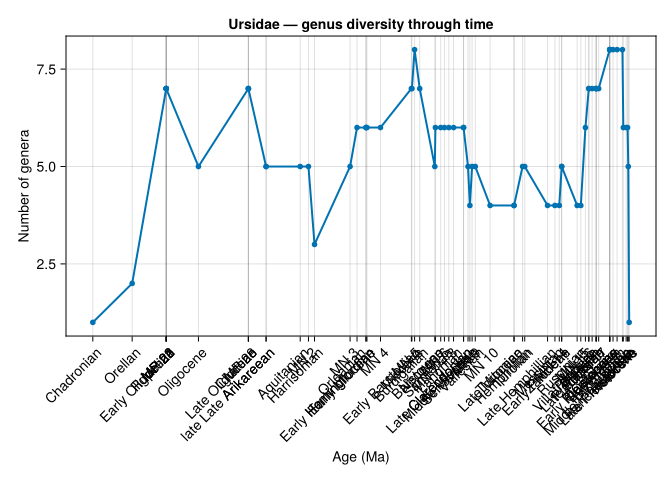

```julia
fig = Figure()
ax = Axis(
    fig[1, 1],
    xlabel = "Age (Ma)",
    ylabel = "Number of genera",
    title = "Ursidae — genus diversity through time",
    xticks = (interval_df.interval_mid_ma, interval_df.early_interval),
    xticklabelrotation = π/4,
    xreversed = true,
)

lines!(ax, interval_df.interval_mid_ma, interval_df.diversity, linewidth = 2)
scatter!(ax, interval_df.interval_mid_ma, interval_df.diversity, markersize = 8)

fig
```

## 2.10 Complete program

```julia
using DataFrames
using PaleobiologyDB
using PaleobiologyDB.Taxonomy
using Makie, CairoMakie

set_autocaching!(true)

df = pbdb_occurrences(
    base_name = "Ursidae";
    show = "full",
    vocab = "pbdb"
)

df = dropmissing(df, [
    :genus,
    :early_interval,
    :max_ma,
    :min_ma
])

# Following runs both:
# - `df = Taxonomy.drop_unresolved_taxa(df, "genus")`
# - `df = Taxonomy.drop_unrecognized_taxa(df, :genus)`
df = Taxonomy.drop_unqualified_taxa(df, "genus")

df.midpoint_age = (df.max_ma .+ df.min_ma) ./ 2

interval_df = combine(
    groupby(df, :early_interval),
    :max_ma => maximum => :interval_max_ma,
    :min_ma => minimum => :interval_min_ma,
)

interval_df.interval_mid_ma = (interval_df.interval_max_ma .+ interval_df.interval_min_ma) ./ 2

interval_df = sort(interval_df, :interval_mid_ma, rev=true)

interval_df

genus_ranges = combine(
    groupby(df, :genus),
    :midpoint_age => maximum => :fad_ma,
    :midpoint_age => minimum => :lad_ma,
)

diversity = Int[]

for interval_row in eachrow(interval_df)
    n = count(
        g -> g.fad_ma >= interval_row.interval_mid_ma >= g.lad_ma,
        eachrow(genus_ranges)
    )
    push!(diversity, n)
end

interval_df.diversity = diversity

fig = Figure()
ax = Axis(
    fig[1, 1],
    xlabel = "Age (Ma)",
    ylabel = "Number of genera",
    title = "Ursidae — genus diversity through time",
    xticks = (interval_df.interval_mid_ma, interval_df.early_interval),
    xticklabelrotation = π/4,
    xreversed = true,
)

lines!(ax, interval_df.interval_mid_ma, interval_df.diversity, linewidth = 2)
scatter!(ax, interval_df.interval_mid_ma, interval_df.diversity, markersize = 8)

fig
```

## 2.11 Exercises: Evaluating richness through time — standard binning method

### 2.11.1 Julia concepts and mechanisms

For each snippet, predict the output before running it in the REPL.

#### 2.11.1.1 Part A: Anonymous functions

1. A named anonymous function:

   ```julia
   f = x -> x * 2
   println(f(5))
   ```

   **NoteAnswer**

   ```
   10
   ```

   `x -> x * 2` defines an unnamed function; assigning it to `f` lets you call it like any other function.
2. Testing a condition:

   ```julia
   f = x -> x > 10
   println(f(5))
   println(f(15))
   ```

   **NoteAnswer**

   ```
   false
   true
   ```

3. Anonymous function inline in `count`:

   ```julia
   println(count(x -> x > 0, [-1, 2, -3, 4, 5]))
   ```

   **NoteAnswer**

   ```
   3
   ```

   `count` applies the condition to every element and tallies the `true` results. The positive values are 2, 4, 5 — three of them.
4. Counting strings by length:

   ```julia
   names = ["cat", "dog", "bear", "fox"]
   println(count(n -> length(n) == 3, names))
   ```

   **NoteAnswer**

   ```
   3
   ```

   “cat”, “dog”, and “fox” all have length 3; “bear” has length 4.
5. Threshold count:

   ```julia
   ages = [5.0, 12.0, 3.0, 7.0, 20.0]
   println(count(a -> a >= 7.0, ages))
   ```

   **NoteAnswer**

   ```
   3
   ```

   Values ≥ 7.0: `12.0`, `7.0`, `20.0`.
6. Anonymous function with arithmetic:

   ```julia
   f = x -> x^2 + 1
   println(f(3))
   println(f(0))
   ```

   **NoteAnswer**

   ```
   10
   1
   ```

   `f(3) = 3^2 + 1 = 10`; `f(0) = 0 + 1 = 1`.

#### 2.11.1.2 Part B: `push!` and building vectors incrementally

1. Basic `push!`:

   ```julia
   v = Int[]
   push!(v, 10)
   push!(v, 20)
   push!(v, 30)
   println(v)
   ```

   **NoteAnswer**

   ```
   [10, 20, 30]
   ```

   `Int[]` starts as an empty integer vector. Each `push!` appends one element in place.
2. `push!` inside a loop:

   ```julia
   v = Int[]
   for i in 1:5
       push!(v, i * 2)
   end
   println(v)
   ```

   **NoteAnswer**

   ```
   [2, 4, 6, 8, 10]
   ```

3. Length after pushing:

   ```julia
   ages = Float64[]
   push!(ages, 3.5)
   push!(ages, 7.2)
   println(length(ages))
   ```

   **NoteAnswer**

   ```
   2
   ```

4. Conditional `push!`:

   ```julia
   v = Int[]
   for i in 1:6
       if i % 2 == 0
           push!(v, i)
       end
   end
   println(v)
   ```

   **NoteAnswer**

   ```
   [2, 4, 6]
   ```

   Only even values of `i` satisfy `i % 2 == 0`.
5. `count` with a bracketing condition:

   ```julia
   ages = [5.0, 15.0, 25.0, 35.0, 45.0]
   println(count(a -> 10.0 <= a <= 30.0, ages))
   ```

   **NoteAnswer**

   ```
   2
   ```

   `15.0` and `25.0` satisfy `10.0 ≤ a ≤ 30.0`; the others do not.
6. Counting even numbers:

   ```julia
   data = [1, 2, 3, 4, 5, 6, 7, 8, 9, 10]
   println(count(x -> x % 2 == 0, data))
   ```

   **NoteAnswer**

   ```
   5
   ```

   Even numbers from 1 to 10: 2, 4, 6, 8, 10.

#### 2.11.1.3 Part C: `eachrow` iteration

1. Iterating over rows by name:

   ```julia
   using DataFrames
   df = DataFrame(name = ["A", "B", "C"], val = [1, 2, 3])
   for row in eachrow(df)
       println(row.name, ": ", row.val)
   end
   ```

   **NoteAnswer**

   ```
   A: 1
   B: 2
   C: 3
   ```

   `eachrow` yields each row as a named object; `row.name` and `row.val` access fields by column name instead of numeric index.
2. Computing with `eachrow` and `push!`:

   ```julia
   using DataFrames
   df = DataFrame(fad = [10.0, 20.0, 30.0], lad = [2.0, 5.0, 10.0])
   durations = Float64[]
   for row in eachrow(df)
       push!(durations, row.fad - row.lad)
   end
   println(durations)
   ```

   **NoteAnswer**

   ```
   [8.0, 15.0, 20.0]
   ```

   Row-by-row: `10−2=8`, `20−5=15`, `30−10=20`.
3. `count` over `eachrow`:

   ```julia
   using DataFrames
   genus_ranges = DataFrame(
       fad_ma = [50.0, 30.0, 10.0],
       lad_ma = [20.0,  5.0,  1.0],
   )
   n = count(g -> g.fad_ma >= 25.0 >= g.lad_ma, eachrow(genus_ranges))
   println(n)
   ```

   **NoteAnswer**

   ```
   2
   ```

   Row 1: `50 ≥ 25 ≥ 20` → true. Row 2: `30 ≥ 25 ≥ 5` → true. Row 3: `10 ≥ 25`? No → false.
4. `eachrow` vs. index loop — same output?

   ```julia
   using DataFrames
   df = DataFrame(x = [10, 20, 30])

   for row in eachrow(df)
       print(row.x, " ")
   end
   println()

   for i in 1:nrow(df)
       print(df.x[i], " ")
   end
   println()
   ```

   **NoteAnswer**

   ```
   10 20 30
   10 20 30
   ```

   Both loops produce the same output. `eachrow` is tidier when you do not need the row number.
5. Accumulating a sum with `push!` then summing:

   ```julia
   v = Float64[]
   for i in 1:4
       push!(v, i * 1.5)
   end
   println(v)
   println(sum(v))
   ```

   **NoteAnswer**

   ```
   [1.5, 3.0, 4.5, 6.0]
   15.0
   ```

   `1.5 + 3.0 + 4.5 + 6.0 = 15.0`.
6. How many rows does `eachrow` iterate over?

   ```julia
   using DataFrames
   df = DataFrame(a = 1:7, b = 11:17)
   n = 0
   for row in eachrow(df)
       n += 1
   end
   println(n)
   ```

   **NoteAnswer**

   ```
   7
   ```

   `eachrow` iterates once per row; `nrow(df) = 7`.

#### 2.11.1.4 Part D: Chained comparisons

1. A simple chained comparison:

   ```julia
   x = 15.0
   println(10.0 <= x <= 20.0)
   ```

   **NoteAnswer**

   ```
   true
   ```

2. Chained comparison that fails at the second step:

   ```julia
   x = 25.0
   println(10.0 <= x <= 20.0)
   ```

   **NoteAnswer**

   ```
   false
   ```

   `10.0 ≤ 25.0` is true, but `25.0 ≤ 20.0` is false, so the whole expression is false.
3. Chained comparison as an anonymous function:

   ```julia
   in_range = x -> 10.0 <= x <= 30.0
   println(in_range(20.0))
   println(in_range(35.0))
   ```

   **NoteAnswer**

   ```
   true
   false
   ```

4. Three-variable chain:

   ```julia
   a, b, c = 5.0, 10.0, 15.0
   println(a <= b <= c)
   println(c >= b >= a)
   ```

   **NoteAnswer**

   ```
   true
   true
   ```

   Both orderings express the same relationship: `a ≤ b ≤ c`.
5. Chain that fails at the first step:

   ```julia
   println(5 < 3 < 10)
   ```

   **NoteAnswer**

   ```
   false
   ```

   `5 < 3` is false; Julia short-circuits and the whole expression is false.
6. FAD/LAD bracket check:

   ```julia
   fad = 30.0
   lad = 5.0
   interval_mid = 15.0
   println(fad >= interval_mid >= lad)
   ```

   **NoteAnswer**

   ```
   true
   ```

   `30.0 ≥ 15.0` and `15.0 ≥ 5.0`: the interval midpoint falls within the genus range.
7. Difference between `>=` at the boundary:

   ```julia
   fad = 15.0
   lad = 5.0
   interval_mid = 15.0
   println(fad >= interval_mid >= lad)   # non-strict
   println(fad >  interval_mid >  lad)   # strict
   ```

   **NoteAnswer**

   ```
   true
   false
   ```

   With `>=`, a genus whose FAD equals the interval midpoint is counted as present. With `>`, it is not — the strict version requires the FAD to be *older* than the midpoint. (We will return to this distinction in the next tutorial.)

#### 2.11.1.5 Part E: DataFrame constructor and plotting

1. Building a DataFrame from existing vectors:

   ```julia
   using DataFrames
   boundary_ma = [10.0, 20.0, 30.0]
   diversity   = [3, 5, 4]
   df = DataFrame(boundary_ma = boundary_ma, diversity = diversity)
   println(nrow(df))
   println(df.diversity[2])
   ```

   **NoteAnswer**

   ```
   3
   5
   ```

   `DataFrame(col = vec, ...)` constructs a DataFrame directly from named vectors. `df.diversity[2]` is the second element: `5`.
2. What does `xticks = (positions, labels)` do?

   ```julia
   positions = [1.0, 2.0, 3.0]
   labels    = ["Early", "Middle", "Late"]
   # Axis(..., xticks = (positions, labels))
   ```

   No running needed — describe the effect.

   **NoteAnswer**

   Tick marks are placed at x-coordinates `1.0`, `2.0`, `3.0`, with the text labels “Early”, “Middle”, “Late” shown at those positions. This replaces the automatic numeric ticks with human-readable interval names.
3. The value of `π/4`:

   ```julia
   println(π / 4)
   ```

   **NoteAnswer**

   ```
   0.7853981633974483
   ```

   This is 45° in radians — used as `xticklabelrotation = π/4` to tilt axis labels so they do not overlap.
4. What do `lines!` and `scatter!` produce together?

   ```julia
   x = [1.0, 2.0, 3.0, 4.0, 5.0]
   y = [2,    5,   3,   7,   4  ]
   # lines!(ax, x, y)
   # scatter!(ax, x, y)
   ```

   No running needed — describe the combined result.

   **NoteAnswer**

   `lines!` draws a continuous line connecting the (x, y) points in order. `scatter!` draws a marker at each (x, y) point. Together they produce a *connected scatter plot*: the line shows the overall shape of the curve, and the markers indicate the individual measured values.
5. Full diversity counting pattern:

   ```julia
   using DataFrames
   genus_ranges = DataFrame(
       genus  = ["A",  "B",  "C",  "D"],
       fad_ma = [40.0, 30.0, 20.0, 10.0],
       lad_ma = [15.0,  5.0,  2.0,  1.0],
   )
   interval_mid = 18.0
   n = count(g -> g.fad_ma >= interval_mid >= g.lad_ma, eachrow(genus_ranges))
   println(n)
   ```

   **NoteAnswer**

   ```
   3
   ```

   A: `40 ≥ 18 ≥ 15` → true. B: `30 ≥ 18 ≥ 5` → true. C: `20 ≥ 18 ≥ 2` → true. D: `10 ≥ 18`? No → false.

### 2.11.2 Practical shorts

*Assume you have completed the tutorial and have `df`, `interval_df`, `genus_ranges`, and `interval_df.diversity` available in your REPL.*

    ```julia
    scatter!(ax, interval_df.interval_mid_ma, interval_df.diversity,
             color = interval_df.diversity, colormap = :viridis,
             markersize = 12)
    ```

25. Change `rev=true` to `rev=false` in the `sort` that orders `interval_df`. How does the diversity curve look? Is the time axis still correct?
26. What happens if you call `push!(diversity, n)` outside the loop (after it ends) instead of inside? Walk through the logic without running it first, then test.
27. Compute a three-interval rolling mean of diversity. For each interval `i` from 2 to `nrow - 1`: `mean = (diversity[i-1] + diversity[i] + diversity[i+1]) / 3` Collect these into a vector and plot it alongside the original curve.
28. Export `interval_df` (with the diversity column) to a CSV file. Install and import CSV (`using CSV`), then: `CSV.write("ursidae_diversity.csv", interval_df)`
29. Try counting diversity using `eachrow(genus_ranges)` vs. iterating `genus_ranges` with a numeric index and comparing the counts. Confirm they match for at least one interval.
30. Check: does every interval in `interval_df` have at least one genus present? Print any interval where diversity is 0.

### 2.11.3 Creative programming

#### 2.11.3.1 Diversity profile comparison for two families

Compute and plot the sampled-in-bin diversity curve for two closely related families (for example Ursidae and Procyonidae, or Felidae and Hyaenidae) on the same figure.

**Objectives**

- Run the full pipeline for both families.
- Plot both diversity curves on the same `Axis` using different colors.
- Add a legend identifying each curve.
- Write one or two sentences describing how the diversity histories differ.

**Hints**

- `lines!(ax, x, y, label = "Ursidae", color = :steelblue)` adds a labelled series.
- `axislegend(ax)` draws a legend automatically from the labels.

#### 2.11.3.2 Regional diversity curves

Use the geographic fields in the PBDB occurrence data to compute separate diversity curves for occurrences from North America versus Europe.

**Objectives**

- Filter `df` to two geographic subsets after downloading.
- Run the full pipeline separately for each region.
- Plot the two curves on the same figure and compare.

**Hints**

- The `cc` field in the occurrence data holds the continent code. Filter with `df[df.cc .== "NOA", :]` for North America (code may vary — check the data).
- Both subsets share the same `interval_df`; only the diversity counting step changes.

#### 2.11.3.3 Sampling-corrected diversity

The diversity curve is affected by how well-sampled each interval is. A time interval with more fossil collections will tend to show higher diversity, even if diversity was not actually higher.

**Objectives**

- Add a column `n_occurrences` to `interval_df` counting how many raw occurrence records fall within each interval.
- Plot both raw diversity and occurrence count as two lines on a dual-axis figure.
- Comment on intervals where the two curves diverge.

**Hints**

- Use split-apply-combine on `df` grouped by `:early_interval` with `:early_interval => length => :n_occurrences` to count occurrences per interval.
- A second y-axis can be added in Makie with `Axis` placed at `fig[1, 1]` with a `yaxisposition = :right` argument.

#### 2.11.3.4 Origination and extinction counts

At each stratigraphic interval, some genera appear for the first time (originations) and some disappear (extinctions). Plot these alongside the diversity curve.

**Objectives**

- Define an origination as a genus whose FAD falls within an interval’s age range.
- Define an extinction as a genus whose LAD falls within an interval’s age range.
- For each interval, count originations and extinctions.
- Plot diversity, originations, and extinctions on the same figure.

**Hints**

- `count(g -> interval_min <= g.fad_ma <= interval_max, eachrow(genus_ranges))` counts originations for one interval.
- Use different line colors and a legend to distinguish the three curves.

#### 2.11.3.5 Custom equal-time bins

Instead of using PBDB stratigraphic intervals, divide time into equal 5-Ma bins and recompute the diversity curve.

**Objectives**

- Create your own `interval_df` with 5-Ma bins spanning the dataset’s age range.
- Rerun the diversity counting step with these custom bins.
- Plot the custom-bin curve alongside the PBDB-interval curve and compare the shapes.

**Hints**

- You can create evenly spaced bin edges with: `bin_edges = 0.0:5.0:60.0`.
- The midpoint of each bin is `(left_edge + right_edge) / 2`.
- Build a DataFrame from these vectors using `DataFrame(interval_max_ma = ..., interval_min_ma = ..., interval_mid_ma = ...)`.

#### 2.11.3.6 Color-coded diversity scatter

Map the diversity value to color so that each scatter marker is colored by how diverse the fauna was at that time.

**Objectives**

- Replace the uniform scatter markers with color-mapped ones using a viridis or plasma colormap.
- Add a `Colorbar` to the figure showing the diversity scale.
- Try at least two different colormaps and choose the one you find most readable.

**Hints**

- `scatter!(ax, x, y, color = diversity, colormap = :plasma, markersize = 12)` maps the `diversity` vector to the colormap.
- `Colorbar(fig[1, 2], colormap = :plasma, limits = (0, maximum(diversity)))` adds a vertical colorbar next to the plot.

#### 2.11.3.7 Persistence through time

Instead of raw diversity, compute the *persistence fraction* at each interval: what fraction of the genera present in interval `i` are still present in interval `i+1`?

**Objectives**

- For each pair of adjacent intervals, compute how many genera span both.
- Express this as a fraction of the diversity in the older interval.
- Plot the persistence fraction as a curve.
- Identify intervals with the lowest persistence (largest faunal turnovers).

**Hints**

- You will need the diversity counts for both intervals simultaneously; iterate with an index loop rather than `eachrow`.
- A persistence fraction close to 1.0 means nearly all genera survived; close to 0 means near-total turnover.

#### 2.11.3.8 Diversity for a deep-time taxon

Apply the pipeline to a group with a much longer fossil record than Ursidae — for example Crocodilia or Testudines (turtles) — spanning hundreds of millions of years.

**Objectives**

- Download and clean the data; note how many intervals are returned.
- Run the diversity pipeline and plot the result.
- Identify the interval of peak diversity.
- Describe one paleobiological event visible in the diversity curve.

**Hints**

- Very old data may have large age uncertainties; the midpoint calculation still applies.
- The diversity curve may be noisy at the oldest end where sampling is sparse.

#### 2.11.3.9 The Makie gallery

Browse the Makie documentation examples gallery and find one chart type you have not used yet — for example a violin plot, heatmap, ridgeline, or step plot.

**Objectives**

- Choose a plot type from the gallery.
- Adapt it to display something meaningful about the Ursidae dataset.
- Add appropriate labels and a title.

**Hints**

- The Makie documentation is at `docs.makie.org`.
- You already know how to build the Ursidae data; the challenge is choosing the right visual encoding and adapting the syntax from the example.

#### 2.11.3.10 Comparing diversity methods across five families

For five mammal families of your choice, compute the sampled-in-bin diversity at its peak interval and compare across families.

**Objectives**

- Run the full pipeline for each family.
- Record the peak diversity and the interval at which it occurs.
- Create a bar chart comparing peak diversities across the five families.
- Label each bar with the family name and the interval.

**Hints**

- A `for` loop over family names keeps the code compact.
- `barplot!(ax, 1:5, peak_diversities)` draws the bars; use `ax.xticks` to add family name labels.

# 3 Evaluating richness through time: range-through method

## 3.1 Objectives

In the previous tutorial we counted how many genera were *present* inside each stratigraphic interval, interpolating across gaps.

This tutorial uses a subtly different approach: the **range-through method**. Instead of asking “which genera were present *in* this interval?”, we ask “which genera were present *across* this interval boundary?” — meaning: observed both *before* and *after* a given point in time.

A genus counts toward the diversity at a boundary only if it has occurrences **both** older and younger than that boundary. This is a stricter requirement, and it means we are measuring taxa that genuinely co-existed in time, rather than taxa whose ranges merely happen to span an interval by interpolation.

**NoteRange-through vs sampled-in-bin**

The **sampled-in-bin** method (previous tutorial) counts every genus whose range spans an interval, including genera whose ranges only *touch* the interval at one end. The **range-through** method counts only genera that have documented occurrences on *both sides* of a boundary. It is more conservative but less susceptible to edge effects at the FAD or LAD.

The change to the code from the previous tutorial is small: one condition in the `count` call.

## 3.2 Environment setup

```julia
using DataFrames
using PaleobiologyDB
using PaleobiologyDB.Taxonomy
using Makie, CairoMakie

set_autocaching!(true)
```

## 3.3 Data acquisition

```julia
df = pbdb_occurrences(
    base_name = "Ursidae";
    show = "full",
    vocab = "pbdb"
)
```

**Code Output**

1026×136 DataFrame

36 columns and 1001 rows omitted

| Row | occurrence_no Int64 | record_type String3 | reid_no Int64? | flags Missing | collection_no Int64 | identified_name String | identified_rank String15 | identified_no Int64 | difference String? | accepted_name String | accepted_attr Missing | accepted_rank String15 | accepted_no Int64 | early_interval String31 | late_interval String31? | max_ma Float64 | min_ma Float64 | ref_author String | ref_pubyr Int64 | reference_no Int64 | phylum String15 | class String15 | order String15 | family String7 | genus String31? | plant_organ Missing | abund_value Float64? | abund_unit String15? | lng Float64 | … |
| --- | --- | --- | --- | --- | --- | --- | --- | --- | --- | --- | --- | --- | --- | --- | --- | --- | --- | --- | --- | --- | --- | --- | --- | --- | --- | --- | --- | --- | --- | --- |
| 1 | 138737 | occ | missing | missing | 11798 | Indarctos sinensis | species | 90198 | missing | Indarctos atticus | missing | species | 90196 | Tortonian | missing | 11.63 | 7.246 | Qi 1985 | 1985 | 11437 | Chordata | Mammalia | Carnivora | Ursidae | Indarctos | missing | missing | missing | 102.067 | … |
| 2 | 138739 | occ | missing | missing | 11798 | Ursinae indet. | subfamily | 65407 | missing | Ursinae | missing | subfamily | 65407 | Tortonian | missing | 11.63 | 7.246 | Qi 1985 | 1985 | 10885 | Chordata | Mammalia | Carnivora | Ursidae | missing | missing | missing | missing | 102.067 | … |
| 3 | 150068 | occ | missing | missing | 13293 | Ursus thibetanus | species | 104029 | missing | Ursus thibetanus | missing | species | 104029 | Middle Pleistocene | Late Pleistocene | 0.774 | 0.0117 | Huang et al. 1988 | 1988 | 4412 | Chordata | Mammalia | Carnivora | Ursidae | Ursus | missing | missing | missing | 111.567 | … |
| 4 | 150069 | occ | missing | missing | 13293 | Ailuropoda melanoleuca | species | 104016 | missing | Ailuropoda melanoleuca | missing | species | 104015 | Middle Pleistocene | Late Pleistocene | 0.774 | 0.0117 | Huang et al. 1988 | 1988 | 4412 | Chordata | Mammalia | Carnivora | Ursidae | Ailuropoda | missing | missing | missing | 111.567 | … |
| 5 | 177833 | occ | missing | missing | 16885 | Parictis parvus n. sp. | species | 50003 | missing | Parictis parvus | missing | species | 50003 | Chadronian | missing | 37.0 | 33.9 | Clark and Beerbower 1967 | 1967 | 1235 | Chordata | Mammalia | Carnivora | Ursidae | Parictis | missing | missing | missing | -102.45 | … |
| 6 | 177834 | occ | missing | missing | 16885 | Parictis gilpini n. sp. | species | 50000 | missing | Parictis gilpini | missing | species | 50000 | Chadronian | missing | 37.0 | 33.9 | Clark and Guensburg 1972 | 1972 | 1238 | Chordata | Mammalia | Carnivora | Ursidae | Parictis | missing | missing | missing | -102.45 | … |
| 7 | 177925 | occ | 3434 | missing | 16907 | Parictis personi | species | 50004 | missing | Parictis personi | missing | species | 44820 | Chadronian | missing | 37.0 | 33.9 | Alroy 2002 | 2002 | 6294 | Chordata | Mammalia | Carnivora | Ursidae | Parictis | missing | missing | missing | -108.2 | … |
| 8 | 178031 | occ | missing | missing | 16919 | Parictis parvus | species | 50003 | missing | Parictis parvus | missing | species | 50003 | Chadronian | missing | 37.0 | 33.9 | Storer 1996 | 1996 | 3318 | Chordata | Mammalia | Carnivora | Ursidae | Parictis | missing | missing | missing | -109.883 | … |
| 9 | 178233 | occ | missing | missing | 16933 | Parictis gilpini | species | 50000 | missing | Parictis gilpini | missing | species | 50000 | Chadronian | missing | 37.0 | 33.9 | Clark and Guensburg 1972 | 1972 | 1238 | Chordata | Mammalia | Carnivora | Ursidae | Parictis | missing | missing | missing | -104.5 | … |
| 10 | 178370 | occ | missing | missing | 16946 | Parictis montanus | species | 50002 | missing | Parictis montanus | missing | species | 50002 | Chadronian | missing | 37.0 | 33.9 | Clark and Guensburg 1972 | 1972 | 1238 | Chordata | Mammalia | Carnivora | Ursidae | Parictis | missing | 1.0 | specimens | -112.8 | … |
| 11 | 178414 | occ | missing | missing | 16958 | Parictis gilpini | species | 50000 | missing | Parictis gilpini | missing | species | 50000 | Chadronian | missing | 37.0 | 33.9 | Clark and Guensburg 1972 | 1972 | 1238 | Chordata | Mammalia | Carnivora | Ursidae | Parictis | missing | missing | missing | -103.1 | … |
| 12 | 178466 | occ | missing | missing | 16960 | Subparictis parvus | species | 51886 | recombined as | Parictis parvus | missing | species | 50003 | Chadronian | missing | 37.0 | 33.9 | Emry 1992 | 1992 | 1442 | Chordata | Mammalia | Carnivora | Ursidae | Parictis | missing | missing | missing | -107.1 | … |
| 13 | 178509 | occ | 10552 | missing | 16961 | Subparictis parvus | species | 51886 | recombined as | Parictis parvus | missing | species | 50003 | Chadronian | missing | 37.0 | 33.9 | Baskin and Tedford 1996 | 1996 | 1034 | Chordata | Mammalia | Carnivora | Ursidae | Parictis | missing | missing | missing | -107.1 | … |
| ⋮ | ⋮ | ⋮ | ⋮ | ⋮ | ⋮ | ⋮ | ⋮ | ⋮ | ⋮ | ⋮ | ⋮ | ⋮ | ⋮ | ⋮ | ⋮ | ⋮ | ⋮ | ⋮ | ⋮ | ⋮ | ⋮ | ⋮ | ⋮ | ⋮ | ⋮ | ⋮ | ⋮ | ⋮ | ⋮ | … |
| 1015 | 1685918 | occ | missing | missing | 238811 | Ursus maritimus | species | 52609 | missing | Ursus maritimus | missing | species | 52609 | Holocene | missing | 0.0117 | 0.0 | Harington 2003 | 2003 | 28440 | Chordata | Mammalia | Carnivora | Ursidae | Ursus | missing | 3.0 | specimens | -86.3833 | … |
| 1016 | 1694649 | occ | missing | missing | 56563 | Ursavus sp. | genus | 41329 | missing | Ursavus | missing | genus | 41329 | Sarmatian | missing | 12.8 | 11.63 | Malik and Nafiz 1933 | 1933 | 91770 | Chordata | Mammalia | Carnivora | Ursidae | Ursavus | missing | missing | missing | 28.7754 | … |
| 1017 | 1702783 | occ | missing | missing | 228489 | Ursus maritimus | species | 52609 | missing | Ursus maritimus | missing | species | 52609 | Holocene | missing | 0.0117 | 0.0 | Crockford 2022 | 2022 | 81667 | Chordata | Mammalia | Carnivora | Ursidae | Ursus | missing | missing | missing | -122.544 | … |
| 1018 | 1702784 | occ | missing | missing | 230285 | Ursus maritimus | species | 52609 | missing | Ursus maritimus | missing | species | 52609 | Holocene | missing | 0.0117 | 0.0 | Crockford 2022 | 2022 | 81667 | Chordata | Mammalia | Carnivora | Ursidae | Ursus | missing | missing | missing | -50.6377 | … |
| 1019 | 1703405 | occ | missing | missing | 227730 | Ursus maritimus | species | 52609 | missing | Ursus maritimus | missing | species | 52609 | Late Pleistocene | missing | 0.129 | 0.0117 | Laursen 1944 | 1944 | 82225 | Chordata | Mammalia | Carnivora | Ursidae | Ursus | missing | missing | missing | 11.9672 | … |
| 1020 | 1706938 | occ | missing | missing | 241995 | Ursus cf. dolinensis | genus | 41331 | species not entered | Ursus | missing | genus | 41331 | Early Pleistocene | missing | 2.58 | 0.774 | Cuenca-Bescós et al. 2010 | 2010 | 92837 | Chordata | Mammalia | Carnivora | Ursidae | Ursus | missing | missing | missing | 3.0 | … |
| 1021 | 1708181 | occ | missing | missing | 242160 | Ursus etruscus | species | 366707 | missing | Ursus etruscus | missing | species | 366707 | Early Pleistocene | missing | 2.58 | 0.774 | Sánchez-Bandera et al. 2025 | 2025 | 92927 | Chordata | Mammalia | Carnivora | Ursidae | Ursus | missing | missing | missing | 15.3847 | … |
| 1022 | 2038384 | occ | missing | missing | 275384 | Ursus americanus | species | 52602 | missing | Ursus americanus | missing | species | 52602 | Quaternary | missing | 2.58 | 0.0 | KellerLynn 2011 | 2011 | 93130 | Chordata | Mammalia | Carnivora | Ursidae | Ursus | missing | missing | missing | -123.407 | … |
| 1023 | 2038385 | occ | missing | missing | 275384 | Ursus arctos | species | 52604 | missing | Ursus arctos | missing | species | 52604 | Quaternary | missing | 2.58 | 0.0 | KellerLynn 2011 | 2011 | 93130 | Chordata | Mammalia | Carnivora | Ursidae | Ursus | missing | missing | missing | -123.407 | … |
| 1024 | 2041253 | occ | missing | missing | 196908 | Ursus arctos | species | 52604 | missing | Ursus arctos | missing | species | 52604 | Holocene | missing | 0.0117 | 0.0 | Detry and Arruda 2013 | 2013 | 93416 | Chordata | Mammalia | Carnivora | Ursidae | Ursus | missing | missing | missing | -8.64325 | … |
| 1025 | 2041322 | occ | missing | missing | 275782 | Ursus sp. | genus | 41331 | missing | Ursus | missing | genus | 41331 | Holocene | missing | 0.0117 | 0.0 | Davis 2006 | 2006 | 93418 | Chordata | Mammalia | Carnivora | Ursidae | Ursus | missing | missing | missing | -8.26563 | … |
| 1026 | 2048229 | occ | missing | missing | 276686 | Ursus cf. etruscus | species | 366707 | missing | Ursus etruscus | missing | species | 366707 | Ionian | missing | 0.774 | 0.129 | Dehm 1962 | 1962 | 93840 | Chordata | Mammalia | Carnivora | Ursidae | Ursus | missing | missing | missing | 11.1153 | … |

## 3.4 Data cleaning

```julia
df = dropmissing(df, [
    :genus,
    :early_interval,
    :max_ma,
    :min_ma
])
df = Taxonomy.drop_unqualified_taxa(df, "genus")
```

**Code Output**

979×136 DataFrame

36 columns and 954 rows omitted

| Row | occurrence_no Int64 | record_type String3 | reid_no Int64? | flags Missing | collection_no Int64 | identified_name String | identified_rank String15 | identified_no Int64 | difference String? | accepted_name String | accepted_attr Missing | accepted_rank String15 | accepted_no Int64 | early_interval String31 | late_interval String31? | max_ma Float64 | min_ma Float64 | ref_author String | ref_pubyr Int64 | reference_no Int64 | phylum String15 | class String15 | order String15 | family String7 | genus String31 | plant_organ Missing | abund_value Float64? | abund_unit String15? | lng Float64 | … |
| --- | --- | --- | --- | --- | --- | --- | --- | --- | --- | --- | --- | --- | --- | --- | --- | --- | --- | --- | --- | --- | --- | --- | --- | --- | --- | --- | --- | --- | --- | --- |
| 1 | 138737 | occ | missing | missing | 11798 | Indarctos sinensis | species | 90198 | missing | Indarctos atticus | missing | species | 90196 | Tortonian | missing | 11.63 | 7.246 | Qi 1985 | 1985 | 11437 | Chordata | Mammalia | Carnivora | Ursidae | Indarctos | missing | missing | missing | 102.067 | … |
| 2 | 150068 | occ | missing | missing | 13293 | Ursus thibetanus | species | 104029 | missing | Ursus thibetanus | missing | species | 104029 | Middle Pleistocene | Late Pleistocene | 0.774 | 0.0117 | Huang et al. 1988 | 1988 | 4412 | Chordata | Mammalia | Carnivora | Ursidae | Ursus | missing | missing | missing | 111.567 | … |
| 3 | 150069 | occ | missing | missing | 13293 | Ailuropoda melanoleuca | species | 104016 | missing | Ailuropoda melanoleuca | missing | species | 104015 | Middle Pleistocene | Late Pleistocene | 0.774 | 0.0117 | Huang et al. 1988 | 1988 | 4412 | Chordata | Mammalia | Carnivora | Ursidae | Ailuropoda | missing | missing | missing | 111.567 | … |
| 4 | 177833 | occ | missing | missing | 16885 | Parictis parvus n. sp. | species | 50003 | missing | Parictis parvus | missing | species | 50003 | Chadronian | missing | 37.0 | 33.9 | Clark and Beerbower 1967 | 1967 | 1235 | Chordata | Mammalia | Carnivora | Ursidae | Parictis | missing | missing | missing | -102.45 | … |
| 5 | 177834 | occ | missing | missing | 16885 | Parictis gilpini n. sp. | species | 50000 | missing | Parictis gilpini | missing | species | 50000 | Chadronian | missing | 37.0 | 33.9 | Clark and Guensburg 1972 | 1972 | 1238 | Chordata | Mammalia | Carnivora | Ursidae | Parictis | missing | missing | missing | -102.45 | … |
| 6 | 177925 | occ | 3434 | missing | 16907 | Parictis personi | species | 50004 | missing | Parictis personi | missing | species | 44820 | Chadronian | missing | 37.0 | 33.9 | Alroy 2002 | 2002 | 6294 | Chordata | Mammalia | Carnivora | Ursidae | Parictis | missing | missing | missing | -108.2 | … |
| 7 | 178031 | occ | missing | missing | 16919 | Parictis parvus | species | 50003 | missing | Parictis parvus | missing | species | 50003 | Chadronian | missing | 37.0 | 33.9 | Storer 1996 | 1996 | 3318 | Chordata | Mammalia | Carnivora | Ursidae | Parictis | missing | missing | missing | -109.883 | … |
| 8 | 178233 | occ | missing | missing | 16933 | Parictis gilpini | species | 50000 | missing | Parictis gilpini | missing | species | 50000 | Chadronian | missing | 37.0 | 33.9 | Clark and Guensburg 1972 | 1972 | 1238 | Chordata | Mammalia | Carnivora | Ursidae | Parictis | missing | missing | missing | -104.5 | … |
| 9 | 178370 | occ | missing | missing | 16946 | Parictis montanus | species | 50002 | missing | Parictis montanus | missing | species | 50002 | Chadronian | missing | 37.0 | 33.9 | Clark and Guensburg 1972 | 1972 | 1238 | Chordata | Mammalia | Carnivora | Ursidae | Parictis | missing | 1.0 | specimens | -112.8 | … |
| 10 | 178414 | occ | missing | missing | 16958 | Parictis gilpini | species | 50000 | missing | Parictis gilpini | missing | species | 50000 | Chadronian | missing | 37.0 | 33.9 | Clark and Guensburg 1972 | 1972 | 1238 | Chordata | Mammalia | Carnivora | Ursidae | Parictis | missing | missing | missing | -103.1 | … |
| 11 | 178466 | occ | missing | missing | 16960 | Subparictis parvus | species | 51886 | recombined as | Parictis parvus | missing | species | 50003 | Chadronian | missing | 37.0 | 33.9 | Emry 1992 | 1992 | 1442 | Chordata | Mammalia | Carnivora | Ursidae | Parictis | missing | missing | missing | -107.1 | … |
| 12 | 178509 | occ | 10552 | missing | 16961 | Subparictis parvus | species | 51886 | recombined as | Parictis parvus | missing | species | 50003 | Chadronian | missing | 37.0 | 33.9 | Baskin and Tedford 1996 | 1996 | 1034 | Chordata | Mammalia | Carnivora | Ursidae | Parictis | missing | missing | missing | -107.1 | … |
| 13 | 178553 | occ | missing | missing | 16962 | Parictis sp. | genus | 41320 | missing | Parictis | missing | genus | 41320 | Chadronian | missing | 37.0 | 33.9 | Emry 1992 | 1992 | 1442 | Chordata | Mammalia | Carnivora | Ursidae | Parictis | missing | missing | missing | -107.1 | … |
| ⋮ | ⋮ | ⋮ | ⋮ | ⋮ | ⋮ | ⋮ | ⋮ | ⋮ | ⋮ | ⋮ | ⋮ | ⋮ | ⋮ | ⋮ | ⋮ | ⋮ | ⋮ | ⋮ | ⋮ | ⋮ | ⋮ | ⋮ | ⋮ | ⋮ | ⋮ | ⋮ | ⋮ | ⋮ | ⋮ | … |
| 968 | 1685918 | occ | missing | missing | 238811 | Ursus maritimus | species | 52609 | missing | Ursus maritimus | missing | species | 52609 | Holocene | missing | 0.0117 | 0.0 | Harington 2003 | 2003 | 28440 | Chordata | Mammalia | Carnivora | Ursidae | Ursus | missing | 3.0 | specimens | -86.3833 | … |
| 969 | 1694649 | occ | missing | missing | 56563 | Ursavus sp. | genus | 41329 | missing | Ursavus | missing | genus | 41329 | Sarmatian | missing | 12.8 | 11.63 | Malik and Nafiz 1933 | 1933 | 91770 | Chordata | Mammalia | Carnivora | Ursidae | Ursavus | missing | missing | missing | 28.7754 | … |
| 970 | 1702783 | occ | missing | missing | 228489 | Ursus maritimus | species | 52609 | missing | Ursus maritimus | missing | species | 52609 | Holocene | missing | 0.0117 | 0.0 | Crockford 2022 | 2022 | 81667 | Chordata | Mammalia | Carnivora | Ursidae | Ursus | missing | missing | missing | -122.544 | … |
| 971 | 1702784 | occ | missing | missing | 230285 | Ursus maritimus | species | 52609 | missing | Ursus maritimus | missing | species | 52609 | Holocene | missing | 0.0117 | 0.0 | Crockford 2022 | 2022 | 81667 | Chordata | Mammalia | Carnivora | Ursidae | Ursus | missing | missing | missing | -50.6377 | … |
| 972 | 1703405 | occ | missing | missing | 227730 | Ursus maritimus | species | 52609 | missing | Ursus maritimus | missing | species | 52609 | Late Pleistocene | missing | 0.129 | 0.0117 | Laursen 1944 | 1944 | 82225 | Chordata | Mammalia | Carnivora | Ursidae | Ursus | missing | missing | missing | 11.9672 | … |
| 973 | 1706938 | occ | missing | missing | 241995 | Ursus cf. dolinensis | genus | 41331 | species not entered | Ursus | missing | genus | 41331 | Early Pleistocene | missing | 2.58 | 0.774 | Cuenca-Bescós et al. 2010 | 2010 | 92837 | Chordata | Mammalia | Carnivora | Ursidae | Ursus | missing | missing | missing | 3.0 | … |
| 974 | 1708181 | occ | missing | missing | 242160 | Ursus etruscus | species | 366707 | missing | Ursus etruscus | missing | species | 366707 | Early Pleistocene | missing | 2.58 | 0.774 | Sánchez-Bandera et al. 2025 | 2025 | 92927 | Chordata | Mammalia | Carnivora | Ursidae | Ursus | missing | missing | missing | 15.3847 | … |
| 975 | 2038384 | occ | missing | missing | 275384 | Ursus americanus | species | 52602 | missing | Ursus americanus | missing | species | 52602 | Quaternary | missing | 2.58 | 0.0 | KellerLynn 2011 | 2011 | 93130 | Chordata | Mammalia | Carnivora | Ursidae | Ursus | missing | missing | missing | -123.407 | … |
| 976 | 2038385 | occ | missing | missing | 275384 | Ursus arctos | species | 52604 | missing | Ursus arctos | missing | species | 52604 | Quaternary | missing | 2.58 | 0.0 | KellerLynn 2011 | 2011 | 93130 | Chordata | Mammalia | Carnivora | Ursidae | Ursus | missing | missing | missing | -123.407 | … |
| 977 | 2041253 | occ | missing | missing | 196908 | Ursus arctos | species | 52604 | missing | Ursus arctos | missing | species | 52604 | Holocene | missing | 0.0117 | 0.0 | Detry and Arruda 2013 | 2013 | 93416 | Chordata | Mammalia | Carnivora | Ursidae | Ursus | missing | missing | missing | -8.64325 | … |
| 978 | 2041322 | occ | missing | missing | 275782 | Ursus sp. | genus | 41331 | missing | Ursus | missing | genus | 41331 | Holocene | missing | 0.0117 | 0.0 | Davis 2006 | 2006 | 93418 | Chordata | Mammalia | Carnivora | Ursidae | Ursus | missing | missing | missing | -8.26563 | … |
| 979 | 2048229 | occ | missing | missing | 276686 | Ursus cf. etruscus | species | 366707 | missing | Ursus etruscus | missing | species | 366707 | Ionian | missing | 0.774 | 0.129 | Dehm 1962 | 1962 | 93840 | Chordata | Mammalia | Carnivora | Ursidae | Ursus | missing | missing | missing | 11.1153 | … |

## 3.5 Computing midpoint ages

```julia
df.midpoint_age = (df.max_ma .+ df.min_ma) ./ 2
```

```
979-element Vector{Float64}:
  9.438
  0.39285000000000003
  0.39285000000000003
 35.45
 35.45
 35.45
 35.45
 35.45
 35.45
 35.45
  ⋮
  0.00585
  0.07035
  1.677
  1.677
  1.29
  1.29
  0.00585
  0.00585
  0.4515
```

## 3.6 Building the interval table and genus ranges

```julia
interval_df = combine(
    groupby(df, :early_interval),
    :max_ma => maximum => :interval_max_ma,
    :min_ma => minimum => :interval_min_ma,
)

interval_df.interval_mid_ma = (
    interval_df.interval_max_ma .+ interval_df.interval_min_ma
) ./ 2

interval_df = sort(interval_df, :interval_mid_ma, rev=true)

genus_ranges = combine(
    groupby(df, :genus),
    :midpoint_age => maximum => :fad_ma,
    :midpoint_age => minimum => :lad_ma,
)
```

34×3 DataFrame

9 rows omitted

| Row | genus String31 | fad_ma Float64 | lad_ma Float64 |
| --- | --- | --- | --- |
| 1 | Indarctos | 14.4 | 4.4665 |
| 2 | Ursus | 12.81 | 0.00585 |
| 3 | Ailuropoda | 3.09 | 0.07035 |
| 4 | Parictis | 35.45 | 32.85 |
| 5 | Drassonax | 32.85 | 32.85 |
| 6 | Ursavus | 24.0 | 6.9075 |
| 7 | Cephalogale | 30.6 | 17.4 |
| 8 | Agriotherium | 14.1865 | 3.05 |
| 9 | Plionarctos | 7.05 | 0.4515 |
| 10 | Hemicyon | 18.45 | 10.95 |
| 11 | Plithocyon | 18.215 | 10.6565 |
| 12 | Phoberocyon | 25.17 | 13.848 |
| 13 | Arctodus | 3.05 | 0.0645 |
| ⋮ | ⋮ | ⋮ | ⋮ |
| 23 | Phoberogale | 30.6 | 21.2 |
| 24 | Wangictis | 30.6 | 30.6 |
| 25 | Metarctos | 8.4815 | 8.4815 |
| 26 | Pachycynodon | 30.6 | 21.745 |
| 27 | Cyonarctos | 25.17 | 25.17 |
| 28 | Zaragocyon | 21.2 | 21.2 |
| 29 | Miomaci | 10.385 | 10.385 |
| 30 | Kretzoiarctos | 10.1775 | 9.438 |
| 31 | Arctotherium (Arctotherium) | 1.677 | 1.677 |
| 32 | Proplesictis | 30.6 | 30.6 |
| 33 | Agriarctos | 8.4815 | 8.4815 |
| 34 | Melursus | 1.29585 | 1.29585 |

## 3.7 Measuring diversity at interval *boundaries*

In the previous tutorial the diversity score was computed *inside* an interval — we checked whether a genus’s range spanned the interval’s midpoint.

A genus counts at that boundary if and only if:

- its FAD is **older** than the boundary (it was already present before), **and**
- its LAD is **younger** than the boundary (it persisted after).

In terms of the midpoint ages we have stored:

```
g.fad_ma  >  boundary_ma  >  g.lad_ma
```

Both inequalities must be **strict** (the genus must be observed on *both sides*, not merely *at* the boundary).

**NoteWhy strict inequalities?**

A genus whose FAD equals the boundary age was first seen *at* the boundary, not before it. We cannot say it was present on the older side. Strict `>` ensures we only count genera with confirmed occurrences on both sides.

### 3.7.1 Extracting the boundary ages

Each pair of adjacent intervals in `interval_df` shares a boundary. There are `nrow(interval_df) - 1` boundaries — one fewer than the number of intervals.

We extract them using an **index range with a step**. You have already seen `1:n` (every integer from 1 to n). Julia ranges can also specify a step:

```julia
1:2:9    # → 1, 3, 5, 7, 9  (step of 2)
```

We do not need a custom step here, but we do need to stop one row short of the end: `1:nrow(interval_df)-1` gives the index of every interval except the last.

```julia
boundary_ages = interval_df.interval_min_ma[1:nrow(interval_df)-1]
boundary_ages
```

```
69-element Vector{Float64}:
 33.9
 31.8
 27.3
 27.3
 27.3
 27.3
 27.3
 23.04
 23.04
 23.04
  ⋮
  0.0
  0.774
  0.4
  0.21
  0.129
  0.0117
  0.0117
  0.014
  0.0
```

### 3.7.2 The diversity loop

The loop structure is the same as before. The only difference is the condition inside `count`: `>` instead of `>=` on both sides of the comparison.

```julia
diversity = Int[]

for b in boundary_ages
    n = count(
        g -> g.fad_ma > b > g.lad_ma,
        eachrow(genus_ranges)
    )
    push!(diversity, n)
end
```

### 3.7.3 Assembling the results table

We need a DataFrame that pairs each boundary age with its diversity count. We build one directly:

```julia
boundary_df = DataFrame(
    boundary_ma = boundary_ages,
    diversity   = diversity,
)
```

69×2 DataFrame

44 rows omitted

| Row | boundary_ma Float64 | diversity Int64 |
| --- | --- | --- |
| 1 | 33.9 | 1 |
| 2 | 31.8 | 0 |
| 3 | 27.3 | 5 |
| 4 | 27.3 | 5 |
| 5 | 27.3 | 5 |
| 6 | 27.3 | 5 |
| 7 | 27.3 | 5 |
| 8 | 23.04 | 5 |
| 9 | 23.04 | 5 |
| 10 | 23.04 | 5 |
| 11 | 23.04 | 5 |
| 12 | 18.5 | 3 |
| 13 | 18.5 | 3 |
| ⋮ | ⋮ | ⋮ |
| 58 | 1.8 | 7 |
| 59 | 0.0117 | 1 |
| 60 | 0.0 | 0 |
| 61 | 0.0 | 0 |
| 62 | 0.774 | 8 |
| 63 | 0.4 | 6 |
| 64 | 0.21 | 6 |
| 65 | 0.129 | 6 |
| 66 | 0.0117 | 1 |
| 67 | 0.0117 | 1 |
| 68 | 0.014 | 1 |
| 69 | 0.0 | 0 |

`DataFrame(col1 = values1, col2 = values2, ...)` is a compact way to construct a DataFrame from scratch when you already have the column vectors.

We need to sort the age order on the x-axis:

```julia
boundary_df = sort(boundary_df, :boundary_ma, rev = true)
```

69×2 DataFrame

44 rows omitted

| Row | boundary_ma Float64 | diversity Int64 |
| --- | --- | --- |
| 1 | 33.9 | 1 |
| 2 | 31.8 | 0 |
| 3 | 27.3 | 5 |
| 4 | 27.3 | 5 |
| 5 | 27.3 | 5 |
| 6 | 27.3 | 5 |
| 7 | 27.3 | 5 |
| 8 | 23.04 | 5 |
| 9 | 23.04 | 5 |
| 10 | 23.04 | 5 |
| 11 | 23.04 | 5 |
| 12 | 20.45 | 3 |
| 13 | 20.0 | 3 |
| ⋮ | ⋮ | ⋮ |
| 58 | 0.4 | 6 |
| 59 | 0.21 | 6 |
| 60 | 0.21 | 6 |
| 61 | 0.129 | 6 |
| 62 | 0.014 | 1 |
| 63 | 0.0117 | 1 |
| 64 | 0.0117 | 1 |
| 65 | 0.0117 | 1 |
| 66 | 0.0117 | 1 |
| 67 | 0.0 | 0 |
| 68 | 0.0 | 0 |
| 69 | 0.0 | 0 |

## 3.8 Plotting the diversity curve

Same pattern as before — `lines!` plus `scatter!`, x-axis reversed. We use `boundary_ma` directly as the x-coordinate; no interval names to label because boundaries sit *between* intervals.

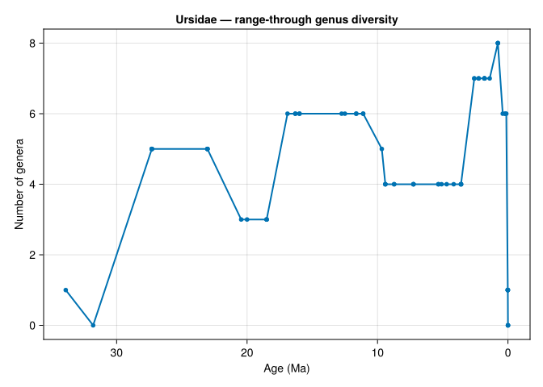

```julia
fig = Figure()
ax = Axis(
    fig[1, 1],
    xlabel = "Age (Ma)",
    ylabel = "Number of genera",
    title  = "Ursidae — range-through genus diversity",
    xreversed = true,
)

lines!(ax, boundary_df.boundary_ma, boundary_df.diversity, linewidth = 2)
scatter!(ax, boundary_df.boundary_ma, boundary_df.diversity, markersize = 8)

fig
```

## 3.9 Complete program

For reference, here is the full program in one place:

```julia
using DataFrames
using PaleobiologyDB
using PaleobiologyDB.Taxonomy
using Makie, CairoMakie

set_autocaching!(true)

df = pbdb_occurrences(
    base_name = "Ursidae";
    show = "full",
    vocab = "pbdb"
)

df = dropmissing(df, [
    :genus,
    :early_interval,
    :max_ma,
    :min_ma
])
df = Taxonomy.drop_unqualified_taxa(df, "genus")

df.midpoint_age = (df.max_ma .+ df.min_ma) ./ 2

interval_df = combine(
    groupby(df, :early_interval),
    :max_ma => maximum => :interval_max_ma,
    :min_ma => minimum => :interval_min_ma,
)

interval_df.interval_mid_ma = (
    interval_df.interval_max_ma .+ interval_df.interval_min_ma
) ./ 2

interval_df = sort(interval_df, :interval_mid_ma, rev=true)

genus_ranges = combine(
    groupby(df, :genus),
    :midpoint_age => maximum => :fad_ma,
    :midpoint_age => minimum => :lad_ma,
)

boundary_ages = interval_df.interval_min_ma[1:nrow(interval_df)-1]
boundary_ages

diversity = Int[]

for b in boundary_ages
    n = count(
        g -> g.fad_ma > b > g.lad_ma,
        eachrow(genus_ranges)
    )
    push!(diversity, n)
end

boundary_df = DataFrame(
    boundary_ma = boundary_ages,
    diversity   = diversity,
)

boundary_df = sort(boundary_df, :boundary_ma, rev = true)

fig = Figure()
ax = Axis(
    fig[1, 1],
    xlabel = "Age (Ma)",
    ylabel = "Number of genera",
    title  = "Ursidae — range-through genus diversity",
    xreversed = true,
)

lines!(ax, boundary_df.boundary_ma, boundary_df.diversity, linewidth = 2)
scatter!(ax, boundary_df.boundary_ma, boundary_df.diversity, markersize = 8)

fig
```

## 3.10 Exercises: Evaluating richness through time — range-through method

### 3.10.1 Julia concepts and mechanisms

For each snippet, predict the output before running it in the REPL.

#### 3.10.1.1 Part A: Strict vs. non-strict inequalities

1. The difference between `>` and `>=`:

   ```julia
   println(5 > 5)
   println(5 >= 5)
   ```

   **NoteAnswer**

   ```
   false
   true
   ```

   `>` requires strictly greater; `>=` allows equality.
2. At a floating-point boundary:

   ```julia
   x = 10.0
   println(x > 10.0)
   println(x >= 10.0)
   ```

   **NoteAnswer**

   ```
   false
   true
   ```

3. FAD equals boundary — range-through or not?

   ```julia
   fad = 30.0
   lad =  5.0
   b   = 30.0
   println(fad > b > lad)    # strict (range-through)
   println(fad >= b >= lad)  # non-strict (sampled-in-bin)
   ```

   **NoteAnswer**

   ```
   false
   true
   ```

   Strict: `30 > 30` is false — the genus was first seen *at* the boundary, not before it, so it cannot be confirmed on the older side. Non-strict: `30 ≥ 30` is true — the genus just barely qualifies.
4. LAD equals boundary:

   ```julia
   fad = 15.0
   lad =  8.0
   b   =  8.0
   println(fad > b > lad)    # strict
   println(fad >= b >= lad)  # non-strict
   ```

   **NoteAnswer**

   ```
   false
   true
   ```

   Strict: `8 > 8` is false — the genus disappeared *at* the boundary, not after it. Non-strict: `8 ≥ 8` is true.
5. How many values exceed a threshold with strict vs. non-strict?

   ```julia
   data = [5.0, 10.0, 15.0, 20.0, 25.0]
   b = 10.0
   println(count(x -> x > b,  data))
   println(count(x -> x >= b, data))
   ```

   **NoteAnswer**

   ```
   3
   4
   ```

   Strict `> 10.0`: 15, 20, 25 (three values). Non-strict `>= 10.0`: 10, 15, 20, 25 (four values).
6. Strict three-way comparison:

   ```julia
   a, b, c = 10.0, 20.0, 10.0
   println(a < b > c)
   ```

   **NoteAnswer**

   ```
   true
   ```

   `10 < 20` is true; `20 > 10` is true; both must hold, and they do.
7. Mixed strict and non-strict:

   ```julia
   println(5 <= 5 < 10)
   println(5 < 5 <= 10)
   ```

   **NoteAnswer**

   ```
   true
   false
   ```

   First: `5 ≤ 5` is true and `5 < 10` is true. Second: `5 < 5` is false — fails at the first step.
8. Comparing range-through and sampled-in-bin at the FAD boundary:

   ```julia
   fad_ma = 25.0
   lad_ma = 10.0
   boundary = 25.0

   range_through  = fad_ma > boundary > lad_ma
   sampled_in_bin = fad_ma >= boundary >= lad_ma

   println("Range-through:  ", range_through)
   println("Sampled-in-bin: ", sampled_in_bin)
   ```

   **NoteAnswer**

   ```
   Range-through:  false
   Sampled-in-bin: true
   ```

   The range-through method requires occurrences *before* the boundary; a genus whose FAD equals the boundary age has no confirmed record on the older side.

#### 3.10.1.2 Part B: Array slicing

1. Extracting a slice:

   ```julia
   v = [10, 20, 30, 40, 50]
   println(v[1:3])
   ```

   **NoteAnswer**

   ```
   [10, 20, 30]
   ```

   `1:3` includes indices 1, 2, and 3.
2. All but the last element — the boundary pattern:

   ```julia
   v = [10, 20, 30, 40, 50]
   n = length(v)
   println(v[1:n-1])
   ```

   **NoteAnswer**

   ```
   [10, 20, 30, 40]
   ```

   `1:n-1` stops one short of the end — exactly how we extract boundary ages from `interval_min_ma`.
3. A middle slice:

   ```julia
   v = [10, 20, 30, 40, 50]
   println(v[2:4])
   ```

   **NoteAnswer**

   ```
   [20, 30, 40]
   ```

4. How many boundaries between `n` intervals?

   ```julia
   intervals = [50.0, 40.0, 30.0, 20.0, 10.0]
   boundaries = intervals[1:length(intervals)-1]
   println(length(boundaries))
   ```

   **NoteAnswer**

   ```
   4
   ```

   Five intervals share four boundaries — one between each adjacent pair.
5. Extracting the younger edges as boundary ages:

   ```julia
   interval_min_ma = [5.3, 2.6, 0.8, 0.0]
   n = length(interval_min_ma)
   boundary_ages = interval_min_ma[1:n-1]
   println(boundary_ages)
   ```

   **NoteAnswer**

   ```
   [5.3, 2.6, 0.8]
   ```

   The last interval’s younger edge (0.0 Ma, the present) is not a shared boundary with any younger interval, so it is excluded.
6. Computing n-1 explicitly:

   ```julia
   n_intervals = 6
   println(n_intervals - 1)
   ```

   **NoteAnswer**

   ```
   5
   ```

7. Slice from index 3 to the end:

   ```julia
   v = [1.0, 2.0, 3.0, 4.0, 5.0]
   println(v[3:end])
   ```

   **NoteAnswer**

   ```
   [3.0, 4.0, 5.0]
   ```

   `3:end` includes every index from 3 onward.
8. Last two elements:

   ```julia
   v = [1.0, 2.0, 3.0, 4.0, 5.0]
   n = length(v)
   println(v[n-1:n])
   ```

   **NoteAnswer**

   ```
   [4.0, 5.0]
   ```

#### 3.10.1.3 Part C: Range-through vs. sampled-in-bin logic

1. Sampled-in-bin counts a genus whose FAD equals the interval midpoint; range-through does not count it at the corresponding boundary:

   ```julia
   fad, lad, mid = 20.0, 5.0, 20.0
   sampled_in_bin    = fad >= mid >= lad
   range_through_rtm = fad >  mid >  lad
   println(sampled_in_bin)
   println(range_through_rtm)
   ```

   **NoteAnswer**

   ```
   true
   false
   ```

2. Range-through count at a boundary with four genera:

   ```julia
   using DataFrames
   genus_ranges = DataFrame(
       fad_ma = [30.0, 20.0, 15.0, 10.0],
       lad_ma = [10.0, 10.0,  5.0,  1.0],
   )
   b = 10.0
   n = count(g -> g.fad_ma > b > g.lad_ma, eachrow(genus_ranges))
   println(n)
   ```

   **NoteAnswer**

   ```
   1
   ```

   Row 1: `30 > 10 > 10`? `10 > 10` is false → no. Row 2: `20 > 10 > 10`? same → no. Row 3: `15 > 10 > 5`? yes → yes. Row 4: `10 > 10`? no → no.
3. Sampled-in-bin count for the same data and midpoint:

   ```julia
   using DataFrames
   genus_ranges = DataFrame(
       fad_ma = [30.0, 20.0, 15.0, 10.0],
       lad_ma = [10.0, 10.0,  5.0,  1.0],
   )
   mid = 10.0
   n = count(g -> g.fad_ma >= mid >= g.lad_ma, eachrow(genus_ranges))
   println(n)
   ```

   **NoteAnswer**

   ```
   4
   ```

   All four rows satisfy `fad_ma ≥ 10 ≥ lad_ma` with non-strict inequalities. Compare to the range-through result above — the method difference is significant for genera whose ranges end exactly at a boundary.
4. How many boundaries does `interval_min_ma[1:n-1]` exclude?

   ```julia
   interval_min_ma = [33.9, 23.0, 5.3, 2.6, 0.8, 0.0]
   n = length(interval_min_ma)
   boundary_ages = interval_min_ma[1:n-1]
   println(length(interval_min_ma) - length(boundary_ages))
   ```

   **NoteAnswer**

   ```
   1
   ```

   One element (the last, representing the present) is excluded.
5. Building `boundary_df` from scratch:

   ```julia
   using DataFrames
   boundary_ages = [20.0, 15.0, 10.0, 5.0]
   diversity     = [3, 5, 4, 2]
   df = DataFrame(boundary_ma = boundary_ages, diversity = diversity)
   println(nrow(df))
   println(df.diversity[2])
   ```

   **NoteAnswer**

   ```
   4
   5
   ```

6. Sorting `boundary_df` from oldest to youngest:

   ```julia
   using DataFrames
   boundary_df = DataFrame(
       boundary_ma = [5.0, 20.0, 10.0, 15.0],
       diversity   = [2,    3,    4,    5  ],
   )
   sorted = sort(boundary_df, :boundary_ma, rev=true)
   println(sorted.boundary_ma)
   ```

   **NoteAnswer**

   ```
   [20.0, 15.0, 10.0, 5.0]
   ```

   `rev=true` places the largest (oldest) values first — the geological convention.
7. Number of boundaries from a five-row interval table:

   ```julia
   using DataFrames
   interval_df = DataFrame(
       name   = ["A",  "B",  "C",  "D",  "E"],
       max_ma = [50.0, 40.0, 30.0, 20.0, 10.0],
       min_ma = [40.0, 30.0, 20.0, 10.0,  0.0],
   )
   println(nrow(interval_df) - 1)
   ```

   **NoteAnswer**

   ```
   4
   ```

   Five intervals → four shared boundaries between them.

#### 3.10.1.4 Part D: Comprehensive mini-pipelines

1. A complete range-through count over three boundaries:

   ```julia
   using DataFrames
   genus_ranges = DataFrame(
       fad_ma = [40.0, 20.0, 10.0],
       lad_ma = [10.0,  5.0,  2.0],
   )
   boundaries = [30.0, 15.0, 7.0]
   diversity = Int[]
   for b in boundaries
       n = count(g -> g.fad_ma > b > g.lad_ma, eachrow(genus_ranges))
       push!(diversity, n)
   end
   println(diversity)
   ```

   **NoteAnswer**

   ```
   [1, 2, 2]
   ```

   Boundary 30.0: only genus 1 (40>30>10) qualifies. Boundary 15.0: genera 1 (40>15>10) and 2 (20>15>5) qualify. Boundary 7.0: genera 2 (20>7>5) and 3 (10>7>2) qualify.
2. Length of the boundary vector:

   ```julia
   interval_min_ma = [33.9, 23.0, 5.3, 2.6, 0.8]
   boundary_ages = interval_min_ma[1:length(interval_min_ma)-1]
   println(length(boundary_ages))
   ```

   **NoteAnswer**

   ```
   4
   ```

   Five intervals → four boundaries.
3. Sampled-in-bin counts more than range-through when FAD aligns with a boundary:

   ```julia
   using DataFrames
   fad_ma = [30.0, 25.0, 20.0, 15.0]
   lad_ma = [ 5.0,  5.0,  5.0,  5.0]
   boundary = 20.0

   gr = DataFrame(fad_ma = fad_ma, lad_ma = lad_ma)
   sib = count(g -> g.fad_ma >= boundary >= g.lad_ma, eachrow(gr))
   rt  = count(g -> g.fad_ma > boundary > g.lad_ma,  eachrow(gr))
   println("SIB: ", sib)
   println("RT:  ", rt)
   ```

   **NoteAnswer**

   ```
   SIB: 3
   RT:  2
   ```

   SIB counts genus 3 (FAD == boundary, satisfies `>=`); RT does not (fails strict `>`).
4. Extracting and printing boundary ages:

   ```julia
   v = [50.0, 40.0, 30.0, 20.0, 10.0, 0.0]
   n = length(v)
   boundaries = v[1:n-1]
   println(boundaries)
   println(length(boundaries))
   ```

   **NoteAnswer**

   ```
   [50.0, 40.0, 30.0, 20.0, 10.0]
   5
   ```

5. A genus whose range is a single point at a boundary:

   ```julia
   fad = 10.0
   lad = 10.0
   b   = 10.0
   println(fad > b > lad)    # strict
   println(fad >= b >= lad)  # non-strict
   ```

   **NoteAnswer**

   ```
   false
   true
   ```

   Strict: `10 > 10` fails on both sides. Non-strict: `10 ≥ 10 ≥ 10` is true — but this is a degenerate case (a point range).
6. Complete mini-pipeline with boundary ages from an interval table:

   ```julia
   using DataFrames
   genus_ranges = DataFrame(
       fad_ma = [50.0, 30.0, 15.0],
       lad_ma = [20.0,  5.0,  1.0],
   )
   interval_min_ma = [40.0, 25.0, 10.0, 2.0]
   n = length(interval_min_ma)
   boundary_ages = interval_min_ma[1:n-1]

   diversity = Int[]
   for b in boundary_ages
       push!(diversity, count(g -> g.fad_ma > b > g.lad_ma, eachrow(genus_ranges)))
   end
   println(diversity)
   ```

   **NoteAnswer**

   ```
   [1, 2, 2]
   ```

   Boundary 40.0: only genus 1 (50>40>20). Boundary 25.0: genera 1 (50>25>20) and 2 (30>25>5). Boundary 10.0: genera 2 (30>10>5) and 3 (15>10>1).
7. A genus with FAD and LAD at the same point cannot range through any boundary:

   ```julia
   fad = 23.5
   lad = 23.5
   boundaries = [23.5, 20.0, 15.0]
   for b in boundaries
       println(fad > b > lad)
   end
   ```

   **NoteAnswer**

   ```
   false
   false
   false
   ```

   When `fad == lad`, the genus occupies a single age point and cannot bracket any boundary on both sides.

### 3.10.2 Practical shorts

*Assume you have completed the tutorial and have `df`, `interval_df`, `genus_ranges`, `boundary_ages`, `boundary_df`, and the diversity curve available in your REPL.*

1. How many boundaries are in `boundary_df`? Compare `nrow(boundary_df)` with `nrow(interval_df)`. What is the difference?
2. Which boundary age has the highest range-through diversity? `boundary_df.boundary_ma[argmax(boundary_df.diversity)]`
3. Which boundary has the lowest diversity? Is it 0? If so, what does that mean biologically?
4. Compute the mean range-through diversity: `sum(boundary_df.diversity) / nrow(boundary_df)`
5. Add a horizontal reference line at the mean diversity: `hlines!(ax, [mean_diversity], color = :gray, linestyle = :dash)`
6. Print all boundary ages where diversity drops compared to the preceding boundary. `diff(boundary_df.diversity)` gives the change between successive values; find where the result is negative.
7. Try changing `>` to `>=` in the boundary loop condition. For which boundaries, if any, does the count change?
8. Plot both the sampled-in-bin diversity curve (from the previous tutorial) and the range-through curve on the same axis in different colors. Add a legend.
9. For each boundary, print the names of the genera that are counted as present. Modify the loop to collect genus names rather than just a count.
10. Which genus appears at the most boundaries? Modify the counting loop to accumulate, for each genus, how many boundaries it spans.
11. What is the first boundary age (oldest) in `boundary_df` when sorted from oldest to youngest?
12. How does `nrow(interval_df) - 1` compare to `length(boundary_ages)`? They should be equal — verify it.
13. Try using `interval_df.interval_max_ma[2:end]` as boundary ages instead of `interval_df.interval_min_ma[1:n-1]`. Are the resulting boundary ages the same? Why or why not?
14. Export `boundary_df` to a CSV file: `CSV.write("ursidae_range_through.csv", boundary_df)`
15. Compute range-through diversity for Felidae and plot it alongside the Ursidae curve.
16. Plot the *difference* between sampled-in-bin and range-through diversity as its own curve. Where is the discrepancy largest?
17. Add larger, filled markers at the three boundaries with the highest diversity. Use a second `scatter!` call with a filtered subset of the data.
18. How many genera in Ursidae have a single-interval range (i.e., `fad_ma` and `lad_ma` fall within the same stratigraphic interval)? These genera cannot contribute to any range-through boundary count.
19. Rerun the range-through analysis using equal 5-Ma bins of your own construction instead of PBDB intervals. Does the shape of the curve change?
20. Create `boundary_df` *without* sorting and plot the diversity curve. What goes wrong visually, and why?
21. After sorting `boundary_df` by `boundary_ma` descending, print the `boundary_ma` column and confirm it runs from largest (oldest) to smallest (youngest).
22. Inspect the genera counted at the oldest boundary. Filter `genus_ranges` manually: which genera satisfy `fad_ma > oldest_boundary > lad_ma`?
23. Compute the maximum single-step drop in diversity between adjacent boundaries: `minimum(diff(boundary_df.diversity))`
24. Apply the range-through pipeline to a much older taxon, such as Crocodilia. Does the pipeline run without modification?
25. Change `markersize = 8` to `markersize = 14`, then try mapping marker size to the diversity value: `scatter!(ax, x, y, markersize = boundary_df.diversity .* 2)`
26. How many boundaries have diversity above 5? `count(x -> x > 5, boundary_df.diversity)`
27. Print the boundary ages where genus *Ursus* contributes to the count. *Ursus* contributes at boundary `b` when `fad_ma > b > lad_ma`; look up its FAD and LAD from `genus_ranges`.
28. Compare the range-through diversity at 10.0 Ma with the sampled-in-bin diversity at the interval whose midpoint is closest to 10.0 Ma. Do they match? If not, which is higher and why?
29. Modify the pipeline so that only genera with at least 3 fossil occurrences are counted toward range-through diversity. (Hint: first compute occurrence counts per genus and filter `genus_ranges` accordingly.)
30. Plot the range-through diversity, sampled-in-bin diversity, and the raw occurrence count per interval all on the same figure. Use a second y-axis for the occurrence count if the scales are very different.

### 3.10.3 Creative programming

#### 3.10.3.1 Three-panel summary figure

Create a single figure summarising all three tutorials in one view: panel 1 shows the genus range chart (tutorial 1), panel 2 the sampled-in-bin diversity curve (tutorial 2), and panel 3 the range-through diversity curve (tutorial 3).

**Objectives**

- Arrange three panels in a single `Figure`: `fig[1,1]`, `fig[2,1]`, `fig[3,1]`.
- Use the same x-axis range and `xreversed = true` on all three panels.
- Add titles to each panel and a shared x-axis label at the bottom.

**Hints**

- `linkxaxes!(ax1, ax2, ax3)` keeps all three panels in sync when you zoom.
- Set `xlabel` only on the bottom panel to avoid repetition.

#### 3.10.3.2 Range-through diversity for deep time

Apply the range-through pipeline to a group with a very long fossil record — for example Crocodilia (spanning the Triassic to the present) or Testudines (turtles).

**Objectives**

- Download and clean the data; note the number of intervals returned.
- Run the range-through pipeline without modification.
- Plot the diversity curve and identify the interval of peak diversity.
- Identify any sharp drops that might correspond to known extinction events.

**Hints**

- Very long-ranging taxa may span hundreds of intervals; the pipeline handles this without changes.
- Look up major extinction events (end-Cretaceous, end-Triassic) and check whether they are visible in the curve.

#### 3.10.3.3 Origination and extinction rates

Use the boundary framework to compute, at each boundary, the number of genera appearing for the first time (originations) and the number disappearing (extinctions).

**Objectives**

- An origination at boundary `b` is a genus whose FAD falls in the interval immediately older than `b` (i.e., `older_interval_max >= fad_ma > b`).
- An extinction at `b` is a genus whose LAD falls in the interval immediately younger than `b`.
- Plot originations, extinctions, and diversity on the same figure with different colors.
- Identify the boundary with the highest extinction rate.

**Hints**

- You will need the interval max/min ages alongside the boundary ages; keep `interval_df` in scope.
- Use a single `Axis` with three `lines!` calls and `axislegend`.

#### 3.10.3.4 Monte Carlo uncertainty bands

The FAD and LAD estimates depend on which age you assign to each occurrence. Quantify this uncertainty.

**Objectives**

- For each occurrence, draw a random age uniformly from its `[min_ma, max_ma]` interval.
- Run the full range-through pipeline on this randomised dataset.
- Repeat 100 times; record the diversity at each boundary for each run.
- Plot the mean diversity curve with a shaded uncertainty band (the 10th–90th percentile).

**Hints**

- `rand() * (max - min) + min` generates a uniform random value between `min` and `max`.
- Collect the 100 diversity vectors into a matrix; compute percentiles column-by-column.
- `band!(ax, x, lower, upper)` draws a shaded region between two curves.

#### 3.10.3.5 Lazarus taxa

A “Lazarus taxon” is a genus that apparently disappears from the fossil record for one or more intervals but then reappears later.

**Objectives**

- For each genus, count how many boundaries it spans (FAD > boundary > LAD).
- Compare this to the number of intervals in which it actually has recorded occurrences.
- Flag genera where the span-to-occurrence ratio is high (spans 5+ boundaries but has occurrences in fewer than half the corresponding intervals).
- List the flagged genera and their apparent gap durations.

**Hints**

- The “span” comes from the range-through logic; the “actual occurrences” require going back to the raw `df` and counting per genus per interval.

#### 3.10.3.6 Global vs. regional range-through diversity

Compare range-through diversity curves for a taxon of your choice restricted to different continents.

**Objectives**

- Filter the cleaned occurrence data to at least two continental regions.
- Run the range-through pipeline independently for each region using the *same* set of intervals.
- Plot the regional curves on the same figure with different colors.
- Describe one pattern that differs between the regions.

**Hints**

- Use the `cc` field (continent code) in the occurrence data. Filter with `df[df.cc .== "NOA", :]` for North America (verify the exact code in your data).
- Keeping the same `interval_df` for both regions ensures the time axes are comparable.

#### 3.10.3.7 Publication-ready diversity figure

Take the range-through diversity curve and upgrade it to a figure suitable for a journal article.

**Objectives**

- Apply a clean, professional color scheme.
- Add labeled vertical lines at major Cenozoic epoch boundaries (Eocene/Oligocene 33.9 Ma, Oligocene/Miocene 23.0 Ma, Miocene/Pliocene 5.3 Ma, Pliocene/Pleistocene 2.6 Ma).
- Use clean axis labels with units.
- Export as PDF or SVG with `save("figure.pdf", fig)`.

**Hints**

- Epoch boundary lines: `vlines!(ax, [33.9, 23.0, 5.3, 2.6], color = :lightgray)`.
- `text!(ax, x, ylims[2], text = "Miocene", fontsize = 9, align = (:center, :top))` places epoch labels at the top of the axes.

#### 3.10.3.8 Comparing methods across five families

For five mammal families of your choice, compute both the sampled-in-bin and range-through diversity at their peak and compare the two methods systematically.

**Objectives**

- For each family, run both pipelines and record the peak diversity and the ratio `range_through_peak / sampled_in_bin_peak`.
- Create a scatter plot: sampled-in-bin peak on the x-axis, range-through peak on the y-axis.
- Add a diagonal line (`y = x`) as a reference.

**Hints**

- Store results in a DataFrame with columns `:family`, `:sib_peak`, `:rt_peak`.
- The diagonal reference line: `lines!(ax, [0, max_val], [0, max_val], linestyle = :dash)`.

#### 3.10.3.9 Custom geological time scale

Replace the PBDB interval boundaries with the formal geological stage boundaries from the International Chronostratigraphic Chart (ICS).

**Objectives**

- Research and hard-code the boundary ages for the Neogene and Quaternary stages (e.g., Gelasian 2.588 Ma, Zanclean 5.333 Ma, Messinian 7.246 Ma, …).
- Build a custom `boundary_ages` vector from these values.
- Run the range-through diversity loop with these boundaries.
- Compare the curve shape with the PBDB-interval version.

**Hints**

- The ICS chart is available at `stratigraphy.org`.
- Hard-code the boundary vector in descending order (oldest first) to match the pipeline’s expected ordering.

#### 3.10.3.10 Interactive slider for minimum occurrence count

Using the GLMakie backend (interactive), add a slider that controls the minimum number of fossil occurrences required for a genus to be included in the range-through count.

**Objectives**

- Install GLMakie (`] add GLMakie`) and replace `using CairoMakie` with `using GLMakie`.
- Add an `Observable` and a `Slider` widget that controls a minimum-occurrences threshold.
- Recompute `genus_ranges` whenever the slider value changes, filtering out genera below the threshold.
- Watch the diversity curve update in real time as you drag the slider.

**Hints**

- `GLMakie.Slider` and `Observable` are the key types; search the Makie documentation for “slider observable”.
- Start with a threshold range of 1 to 10 occurrences.

## 3.11 Appendix: Split-Apply-Combine golf

The split-apply-combine pattern — `combine(groupby(df, key), transforms...)` — is the workhorse of DataFrame analysis in Julia. This appendix gives you two sets of exercises to sharpen your fluency with it.

The first set asks you to *predict* what a given `combine` expression produces. The second set asks you to *write* the most concise expression that produces a specified result — coding golf. All snippets are self-contained; copy them directly into the REPL.

### 3.11.1 Predict the result

For each snippet, work out the output before running it. Every example uses only `DataFrames` and base Julia — no PBDB data required.

1. One summary column:

   ```julia
   using DataFrames
   df = DataFrame(
       group = ["A","A","B","B","B"],
       val   = [1, 3, 2, 4, 6],
   )
   result = combine(groupby(df, :group), :val => sum => :total)
   println(result)
   ```

   **NoteAnswer**

   ```
   2×2 DataFrame
    Row │ group  total
        │ String  Int64
   ─────┼───────────────
      1 │ A           4
      2 │ B          12
   ```

   Group A: `1+3=4`. Group B: `2+4+6=12`.
2. Two summary columns in one call:

   ```julia
   using DataFrames
   df = DataFrame(
       genus = ["X","X","Y","Y","Y"],
       age   = [10.0, 40.0, 5.0, 15.0, 20.0],
   )
   result = combine(
       groupby(df, :genus),
       :age => maximum => :fad,
       :age => minimum => :lad,
   )
   println(result.fad)
   println(result.lad)
   ```

   **NoteAnswer**

   ```
   [40.0, 20.0]
   [10.0, 5.0]
   ```

   X: max=40, min=10. Y: max=20, min=5.
3. Counting rows per group with `length`:

   ```julia
   using DataFrames
   df = DataFrame(
       family = ["Bear","Bear","Bear","Cat","Cat"],
       genus  = ["A","B","A","C","D"],
   )
   result = combine(groupby(df, :family), :genus => length => :n)
   println(result.n)
   ```

   **NoteAnswer**

   ```
   [3, 2]
   ```

   `length` counts the number of elements in the group’s column vector — equivalent to counting rows in the group.
4. How many rows does `combine` produce?

   ```julia
   using DataFrames
   df = DataFrame(
       x = ["a","a","b","c","c","c","d"],
       y = 1:7,
   )
   result = combine(groupby(df, :x), :y => sum => :s)
   println(nrow(result))
   ```

   **NoteAnswer**

   ```
   4
   ```

   There are four distinct values in `:x` (a, b, c, d) → four rows in `result`.
5. Applying a custom function:

   ```julia
   using DataFrames
   df = DataFrame(
       group = ["A","A","B","B"],
       val   = [3.0, 7.0, 1.0, 5.0],
   )
   result = combine(
       groupby(df, :group),
       :val => (v -> maximum(v) - minimum(v)) => :range,
   )
   println(result.range)
   ```

   **NoteAnswer**

   ```
   [4.0, 4.0]
   ```

   A: `7−3=4`. B: `5−1=4`. The anonymous function `v -> maximum(v) - minimum(v)` computes the range of each group’s values.
6. `mean` as the aggregation function:

   ```julia
   using DataFrames, Statistics
   df = DataFrame(
       site = ["N","N","S","S","S"],
       temp = [10.0, 14.0, 20.0, 22.0, 24.0],
   )
   result = combine(groupby(df, :site), :temp => mean => :mean_temp)
   println(result.mean_temp)
   ```

   **NoteAnswer**

   ```
   [12.0, 22.0]
   ```

   N: `(10+14)/2 = 12`. S: `(20+22+24)/3 = 22`.
7. Counting unique values per group:

   ```julia
   using DataFrames
   df = DataFrame(
       region = ["E","E","E","W","W"],
       taxon  = ["Bear","Bear","Cat","Dog","Bear"],
   )
   result = combine(
       groupby(df, :region),
       :taxon => (t -> length(unique(t))) => :n_taxa,
   )
   println(result.n_taxa)
   ```

   **NoteAnswer**

   ```
   [2, 2]
   ```

   East: unique taxa are Bear and Cat → 2. West: Bear and Dog → 2.
8. Chaining `sort` after `combine`:

   ```julia
   using DataFrames
   df = DataFrame(
       sp    = ["B","A","A","C","B","C","C"],
       count = [1,  2,  3,  4,  5,  6,  7],
   )
   result = combine(groupby(df, :sp), :count => sum => :total)
   result = sort(result, :total, rev=true)
   println(result.sp)
   ```

   **NoteAnswer**

   ```
   ["C", "B", "A"]
   ```

   Totals: A=5, B=6, C=17. Sorted descending: C, B, A.
9. `nrow` as the aggregation function:

   ```julia
   using DataFrames
   df = DataFrame(
       stage  = ["Mio","Mio","Plio","Plio","Plio","Plei"],
       taxon  = ["A","B","A","C","D","A"],
   )
   result = combine(groupby(df, :stage), nrow => :count)
   println(result.count)
   ```

   **NoteAnswer**

   ```
   [2, 3, 1]
   ```

   `nrow` (without a column specification) counts rows directly in each group. Miocene: 2 rows. Pliocene: 3. Pleistocene: 1.
10. Multiple groups — two-column groupby:

    ```julia
    using DataFrames
    df = DataFrame(
        continent = ["EU","EU","NA","NA","NA"],
        family    = ["Bear","Cat","Bear","Bear","Cat"],
        n         = [3, 1, 5, 2, 4],
    )
    result = combine(
        groupby(df, [:continent, :family]),
        :n => sum => :total,
    )
    println(nrow(result))
    println(result.total)
    ```

    ```julia
    using DataFrames
    df = DataFrame(g = ["A","A","B"], v = [1,2,3])
    result = combine(groupby(df, :g), :v => sum)
    println(names(result))
    ```

    **NoteAnswer**

    ```
    ["g", "v_sum"]
    ```

    When you write `:v => sum` without the third `=>`, DataFrames automatically names the result column after the source column and the function: `v_sum`.
12. `first` and `last` as aggregation functions:

    ```julia
    using DataFrames
    df = DataFrame(
        grp = ["A","A","A","B","B"],
        val = [10, 20, 30, 40, 50],
    )
    result = combine(
        groupby(df, :grp),
        :val => first => :earliest,
        :val => last  => :latest,
    )
    println(result.earliest)
    println(result.latest)
    ```

    **NoteAnswer**

    ```
    [10, 40]
    [30, 50]
    ```

    `first` takes the first element of the group’s column; `last` takes the last.
13. Aggregation producing a Boolean column:

    ```julia
    using DataFrames
    df = DataFrame(
        genus  = ["A","A","B","B","B"],
        extant = [true, false, true, true, true],
    )
    result = combine(
        groupby(df, :genus),
        :extant => any => :any_extant,
    )
    println(result.any_extant)
    ```

    **NoteAnswer**

    ```
    [true, true]
    ```

    `any` returns `true` if at least one element in the group is `true`. Both genera A and B have at least one `true` record.
14. Passing the whole sub-DataFrame to a function:

    ```julia
    using DataFrames
    df = DataFrame(
        group = ["A","A","B","B"],
        x     = [1.0, 3.0, 2.0, 6.0],
        y     = [4.0, 2.0, 5.0, 1.0],
    )
    result = combine(
        groupby(df, :group),
        [:x, :y] => ((x, y) -> sum(x) / sum(y)) => :ratio,
    )
    println(result.ratio)
    ```

    **NoteAnswer**

    ```julia
    using DataFrames
    df = DataFrame(
        genus = ["A","B","B","C"],
        age   = [10.0, 20.0, 30.0, 15.0],
    )
    result = combine(
        groupby(df, :genus),
        :age => maximum => :fad,
        :age => minimum => :lad,
    )
    println(result[result.genus .== "A", [:fad, :lad]])
    ```

    **NoteAnswer**

    ```
    1×2 DataFrame
     Row │ fad     lad
         │ Float64  Float64
    ─────┼──────────────────
       1 │    10.0     10.0
    ```

    When a group has only one row, `maximum` and `minimum` both return that single value — FAD equals LAD, meaning a point range.
16. Sorting within `groupby` using `sort = true`:

    ```julia
    using DataFrames
    df = DataFrame(genus = ["B","A","A","B"], age = [5,10,20,15])
    r1 = combine(groupby(df, :genus; sort=true),  :age => sum => :s)
    r2 = combine(groupby(df, :genus; sort=false), :age => sum => :s)
    println(r1.genus)
    println(r2.genus)
    ```

    **NoteAnswer**

    ```
    ["A", "B"]
    ["B", "A"]
    ```

    `sort=true` orders groups alphabetically. `sort=false` returns groups in the order they are first encountered in `df`.
17. The `identity` function as a passthrough:

    ```julia
    using DataFrames
    df = DataFrame(g = ["X","X","Y"], v = [1,2,3])
    result = combine(groupby(df, :g), :v => identity => :v_copy)
    println(result.v_copy)
    ```

    **NoteAnswer**

    ```
    [1, 2, 3]
    ```

    `identity` returns its argument unchanged. `combine` with `identity` on a column returns all values flattened back into a single column — the group structure is expanded rather than summarised.
18. How many output rows when using `identity`?

    ```julia
    using DataFrames
    df = DataFrame(g = ["A","A","B","B","B"], v = 1:5)
    result_sum  = combine(groupby(df, :g), :v => sum)
    result_iden = combine(groupby(df, :g), :v => identity)
    println(nrow(result_sum))
    println(nrow(result_iden))
    ```

    **NoteAnswer**

    ```
    2
    5
    ```

    `sum` produces one scalar per group → 2 rows. `identity` keeps all values → 5 rows (same as the original DataFrame).
19. Aggregating a string column:

    ```julia
    using DataFrames
    df = DataFrame(
        family = ["Bear","Bear","Cat"],
        genus  = ["Ursus","Ailuropoda","Felis"],
    )
    result = combine(
        groupby(df, :family),
        :genus => (g -> join(g, ", ")) => :genera_list,
    )
    println(result.genera_list)
    ```

    **NoteAnswer**

    ```
    ["Ursus, Ailuropoda", "Felis"]
    ```

    The anonymous function `g -> join(g, ", ")` concatenates the genus names in each group into a single comma-separated string.
20. Nested `combine` calls — summarising the summary:

    ```julia
    using DataFrames
    df = DataFrame(
        continent = ["EU","EU","NA","NA","EU"],
        family    = ["Bear","Cat","Bear","Dog","Bear"],
    )
    # Step 1: count taxa per continent
    step1 = combine(groupby(df, :continent), nrow => :n_taxa)
    # Step 2: find the continent with the most taxa
    println(step1.continent[argmax(step1.n_taxa)])
    ```

    **NoteAnswer**

    ```
    EU
    ```

    EU has 3 rows; NA has 2. `argmax` returns the index of `3`, which corresponds to EU.

### 3.11.2 Coding golf

Each challenge gives you a DataFrame and a target output. Write the shortest correct Julia expression that produces that output using `combine(groupby(...), ...)`. A model solution is in the answer — but there is often more than one way.

1. **Sum per group.**

   ```julia
   using DataFrames
   df = DataFrame(g = ["A","A","B","B"], v = [1,2,3,4])
   # Target: DataFrame with columns :g and :total
   # where :total is the sum of :v per group.
   ```

   **NoteModel solution**

   ```julia
   combine(groupby(df, :g), :v => sum => :total)
   ```

2. **Row count per group.**

   ```julia
   using DataFrames
   df = DataFrame(family = ["Bear","Bear","Cat","Cat","Cat"])
   # Target: DataFrame with columns :family and :n,
   # where :n is the number of rows per family.
   ```

   **NoteModel solution**

   ```julia
   combine(groupby(df, :family), nrow => :n)
   ```

3. **Max and min in one call.**

   ```julia
   using DataFrames
   df = DataFrame(genus = ["X","X","Y"], age = [5.0, 20.0, 8.0])
   # Target: one row per genus with columns :fad (max age) and :lad (min age).
   ```

   **NoteModel solution**

   ```julia
   combine(groupby(df, :genus), :age => maximum => :fad, :age => minimum => :lad)
   ```

4. **Range (max − min) per group.**

   ```julia
   using DataFrames
   df = DataFrame(g = ["A","A","B","B"], v = [1.0, 5.0, 3.0, 3.5])
   # Target: one row per group with column :span = max(v) - min(v).
   ```

   **NoteModel solution**

   ```julia
   combine(groupby(df, :g), :v => (v -> maximum(v) - minimum(v)) => :span)
   ```

5. **Mean per group.**

   ```julia
   using DataFrames, Statistics
   df = DataFrame(site = ["N","N","S","S"], val = [4.0, 8.0, 1.0, 3.0])
   # Target: one row per site with column :avg = mean of val.
   ```

   **NoteModel solution**

   ```julia
   combine(groupby(df, :site), :val => mean => :avg)
   ```

6. **Count unique values per group.**

   ```julia
   using DataFrames
   df = DataFrame(
       region = ["E","E","W","W","W"],
       taxon  = ["Bear","Cat","Bear","Bear","Dog"],
   )
   # Target: one row per region with column :n_unique = number of distinct taxa.
   ```

   **NoteModel solution**

   ```julia
   combine(groupby(df, :region), :taxon => (t -> length(unique(t))) => :n_unique)
   ```

7. **Sorted summary table.**

   ```julia
   using DataFrames
   df = DataFrame(g = ["B","A","B","A","C"], v = [1,2,3,4,5])
   # Target: sum of v per group, sorted by sum descending.
   ```

   **NoteModel solution**

   ```julia
   sort(combine(groupby(df, :g), :v => sum => :s), :s, rev=true)
   ```

8. **Group with the largest sum.**

   ```julia
   using DataFrames
   df = DataFrame(g = ["A","A","B","B","B"], v = [1,2,10,3,4])
   # Target: a single String — the name of the group whose :v sum is largest.
   ```

   **NoteModel solution**

   ```julia
   let r = combine(groupby(df, :g), :v => sum => :s)
       r.g[argmax(r.s)]
   end
   ```

   The `let` block keeps the intermediate result out of the global namespace.
9. **Proportion each group contributes to the total.**

   ```julia
   using DataFrames
   df = DataFrame(g = ["A","A","B","B","B"], v = [1,2,3,4,5])
   # Target: one row per group with column :pct = group sum / overall total * 100.
   ```

   **NoteModel solution**

   ```julia
   let total = sum(df.v)
       combine(groupby(df, :g), :v => (v -> 100 * sum(v) / total) => :pct)
   end
   ```

   The `total` is captured from the outer scope inside the anonymous function.
10. **Boolean: does any row in the group satisfy a condition?**

    ```julia
    using DataFrames
    df = DataFrame(
        genus  = ["A","A","B","B"],
        extant = [true, false, false, false],
    )
    # Target: one row per genus with column :any_extant (Bool).
    ```

    **NoteModel solution**

    ```julia
    combine(groupby(df, :genus), :extant => any => :any_extant)
    ```

11. **Boolean: do all rows in the group satisfy a condition?**

    ```julia
    using DataFrames
    df = DataFrame(
        genus  = ["A","A","B","B"],
        extant = [true, true, true, false],
    )
    # Target: one row per genus with column :all_extant (Bool).
    ```

    **NoteModel solution**

    ```julia
    combine(groupby(df, :genus), :extant => all => :all_extant)
    ```

12. **Concatenate strings per group.**

    ```julia
    using DataFrames
    df = DataFrame(
        family = ["Bear","Bear","Cat"],
        genus  = ["Ursus","Ailuropoda","Felis"],
    )
    # Target: one row per family with column :genera = comma-joined genus names.
    ```

    **NoteModel solution**

    ```julia
    combine(groupby(df, :family), :genus => (g -> join(g, ", ")) => :genera)
    ```

13. **Add group-level statistics back to the original rows.**

    ```julia
    using DataFrames
    df = DataFrame(g = ["A","A","B","B","B"], v = [1,2,3,4,5])
    # Target: the original df with an extra column :group_mean containing
    # the mean of v for that row's group.
    # Hint: use transform instead of combine.
    ```

    **NoteModel solution**

    ```julia
    transform(groupby(df, :g), :v => mean => :group_mean)
    ```

    `transform` is like `combine` but keeps all original rows, broadcasting the group-level result back to every row in the group.
14. **Rank rows within each group.**

    ```julia
    using DataFrames
    df = DataFrame(g = ["A","A","B","B"], v = [10, 30, 5, 20])
    # Target: the original df with a column :rank = position of that row
    # when the group is sorted by v ascending (1 = smallest).
    ```

    **NoteModel solution**

    ```julia
    transform(groupby(df, :g), :v => (v -> sortperm(sortperm(v))) => :rank)
    ```

    `sortperm(v)` gives the indices that would sort `v`; applying `sortperm` again gives the rank of each element.
15. **Normalise values within each group.**

    ```julia
    using DataFrames
    df = DataFrame(g = ["A","A","B","B","B"], v = [2.0, 4.0, 1.0, 3.0, 5.0])
    # Target: a column :v_norm = (v - group_min) / (group_max - group_min)
    # computed within each group.
    ```

    **NoteModel solution**

    ```julia
    transform(
        groupby(df, :g),
        :v => (v -> (v .- minimum(v)) ./ (maximum(v) - minimum(v))) => :v_norm,
    )
    ```

16. **Count rows matching a condition per group.**

    ```julia
    using DataFrames
    df = DataFrame(
        family = ["Bear","Bear","Bear","Cat","Cat"],
        age_ma = [1.0, 5.0, 50.0, 0.5, 10.0],
    )
    # Target: one row per family with column :n_old = count of records with age_ma > 5.
    ```

    **NoteModel solution**

    ```julia
    combine(groupby(df, :family), :age_ma => (a -> count(x -> x > 5, a)) => :n_old)
    ```

17. **Find the row with the maximum value per group.**

    ```julia
    using DataFrames
    df = DataFrame(
        group  = ["A","A","B","B"],
        label  = ["p","q","r","s"],
        score  = [3, 7, 2, 9],
    )
    # Target: one row per group containing the label of the highest-scoring row.
    ```

    **NoteModel solution**

    ```julia
    combine(groupby(df, :group), [:label, :score] => ((l, s) -> l[argmax(s)]) => :best)
    ```

18. **Pivot: count occurrences of each value across groups.**

    ```julia
    using DataFrames
    df = DataFrame(
        continent = ["EU","EU","NA","NA","NA","AS"],
        status    = ["extant","extinct","extant","extant","extinct","extant"],
    )
    # Target: one row per continent with columns :n_extant and :n_extinct.
    ```

    **NoteModel solution**

    ```julia
    combine(
        groupby(df, :continent),
        :status => (s -> count(==("extant"),  s)) => :n_extant,
        :status => (s -> count(==("extinct"), s)) => :n_extinct,
    )
    ```

    `==("extant")` is a partially applied equality function — equivalent to `x -> x == "extant"`.
19. **Running total (cumulative sum) within each group.**

    ```julia
    using DataFrames
    df = DataFrame(g = ["A","A","A","B","B"], v = [1,2,3,10,20])
    # Target: the original df with a column :cumsum_v = cumulative sum of v
    # restarted for each group.
    ```

    **NoteModel solution**

    ```julia
    transform(groupby(df, :g), :v => cumsum => :cumsum_v)
    ```

20. **Two-column groupby: count per (continent, family) pair.**

    ```julia
    using DataFrames
    df = DataFrame(
        continent = ["EU","EU","NA","NA","EU"],
        family    = ["Bear","Cat","Bear","Dog","Bear"],
    )
    # Target: one row per unique (continent, family) pair with column :n = row count.
    ```

    **NoteModel solution**

    ```julia
    combine(groupby(df, [:continent, :family]), nrow => :n)
    ```

Back to top